# modelin_forDSM_PCA

gaohong

2019年7月12日

# 设置工作路径，加载包

```r
library(rgdal)
library(raster)
library(randomForest)
```

# 构建环境因子图层

```r
setwd("E:/soilPaper/modling/EnFactor")

files<-c("DEM.tif","Slope.tif","PlanC.tif","ProfileC.tif","TWI.tif","Bedrock.tif","LSF.tif","VD.tif","RSP.tif")

covStack <- raster(files[1])
for (i in 2:length(files)) {
  covStack <- stack(covStack, files[i])
}

#设置读取样点数据路径
point_shp_folder="E:/soilPaper/modling/allTrainingSamples_shp/"

#设置最终结果tif的保存路径
result_tif_folder="E:/soilPaper/modling/result_mapTif/"

##设置随机数种子
set.seed(2019)

soil_type<-c(1,3,7,20,21,23,30,31,501,502,503)  # 41样本数量太少，删掉。
sampleNum_dict<-list()
```

# PCA8 -ok

## ns3

SNA PCA8 ns3 15

```r
mn="All_pSNA_PCA8_NS3_pen15"

shpPoint<-readOGR(paste(point_shp_folder,mn,".shp",sep = "")) ###
sampData <- extract(covStack, shpPoint, sp = TRUE,method = "simple")

sampData<-sampData@data

sampData<-sampData[sampData$soilID %in% soil_type,]

sampData<-na.omit(sampData)

print(dim(sampData))
```

```
## [1] 1003   10
```

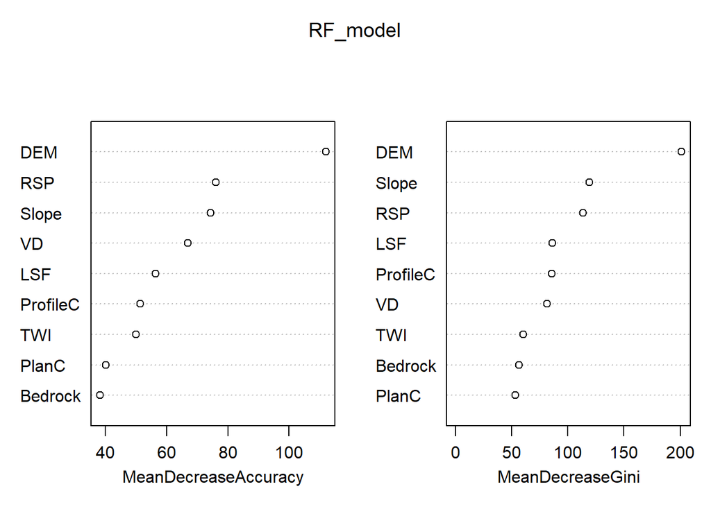

```r
sampleNum_dict[mn]<-nrow(sampData)

sampData$Bedrock<- droplevels(as.factor(sampData$Bedrock))
sampData$soilID<- droplevels(as.factor(sampData$soilID))

RF_model<-randomForest(soilID ~.,data = sampData,
                       importance = TRUE, proximity = FALSE,
                       ntree=1000,type="classification")

varImpPlot(RF_model)
```

```r
print(RF_model)
```

```
##
## Call:
##  randomForest(formula = soilID ~ ., data = sampData, importance = TRUE,      proximity = FALSE, ntree = 1000, type = "classification")
##                Type of random forest: classification
##                      Number of trees: 1000
## No. of variables tried at each split: 3
##
##         OOB estimate of  error rate: 23.33%
## Confusion matrix:
##     1 20 21 23  3 30 31 501 502 503   7 class.error
## 1   4  0  0  0  1  0  0   0   0   0   0  0.20000000
## 20  0 91 17  0  0  0  0   0   0  32  16  0.41666667
## 21  0 29 19  0  0  0  0   0   0   9   0  0.66666667
## 23  0  0  0 83  0  1  2   0   0   9   1  0.13541667
## 3   1  0  0  0 38  0  0  11   0   0   0  0.24000000
## 30  0  0  0  9  0 22  1   0   0   0   0  0.31250000
## 31  0  0  0  3  0  0 38   0   0   0   0  0.07317073
## 501 0  0  0  0 16  0  0 138   1   0   8  0.15337423
## 502 0  4  0  0  0  0  0   3  14   0   1  0.36363636
## 503 0 16  2  9  0  2  0   0   0 204   4  0.13924051
## 7   0 11  0  0  0  2  0   7   0   6 118  0.18055556
```

```r
map_RF <- predict(covStack, RF_model, paste(result_tif_folder,mn,".tif",sep=""),
                  format = "GTiff", datatype = "FLT4S", overwrite = TRUE)

rm("mn","shpPoint","sampData","RF_model","map_RF")
```

SNA PCA8 ns3 30

```r
mn="All_pSNA_PCA8_NS3_pen30"

shpPoint<-readOGR(paste(point_shp_folder,mn,".shp",sep = "")) ###
sampData <- extract(covStack, shpPoint, sp = TRUE,method = "simple")

sampData<-sampData@data

sampData<-sampData[sampData$soilID %in% soil_type,]

sampData<-na.omit(sampData)

print(dim(sampData))
```

```
## [1] 1965   10
```

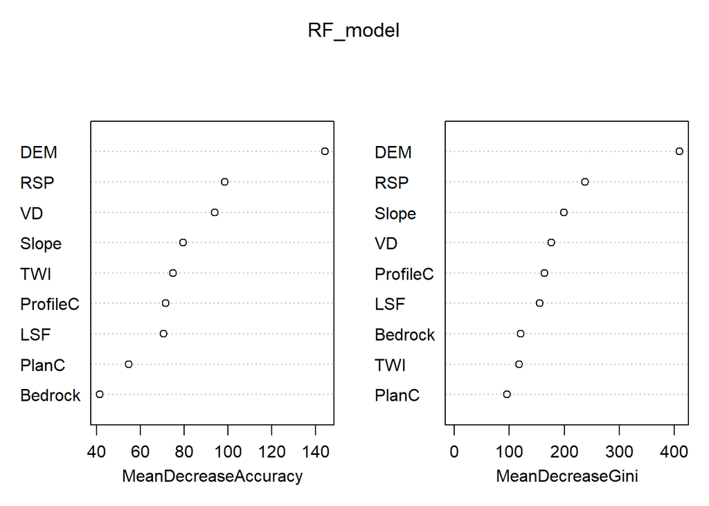

```r
sampleNum_dict[mn]<-nrow(sampData)

sampData$Bedrock<- droplevels(as.factor(sampData$Bedrock))
sampData$soilID<- droplevels(as.factor(sampData$soilID))

RF_model<-randomForest(soilID ~.,data = sampData,
                       importance = TRUE, proximity = FALSE,
                       ntree=1000,type="classification")

varImpPlot(RF_model)
```

```r
print(RF_model)
```

```
##
## Call:
##  randomForest(formula = soilID ~ ., data = sampData, importance = TRUE,      proximity = FALSE, ntree = 1000, type = "classification")
##                Type of random forest: classification
##                      Number of trees: 1000
## No. of variables tried at each split: 3
##
##         OOB estimate of  error rate: 19.49%
## Confusion matrix:
##     1  20 21  23  3 30 31 501 502 503   7 class.error
## 1   5   0  0   0  4  0  0   0   0   0   0  0.44444444
## 20  0 217 19   0  0  0  0   1   0  47  20  0.28618421
## 21  0  42 50   0  0  0  0   0   0  14   1  0.53271028
## 23  0   0  0 157  0  6  5   0   0  17   1  0.15591398
## 3   2   0  0   0 79  0  0  19   0   0   0  0.21000000
## 30  0   0  0   7  0 50  2   0   0   0   3  0.19354839
## 31  0   0  0   3  0  2 75   0   0   1   0  0.07407407
## 501 0   0  0   0 18  0  0 291   0   0  16  0.10461538
## 502 0   4  0   0  0  0  0   2  26   2   6  0.35000000
## 503 0  37  3  14  0  4  0   0   1 401   9  0.14498934
## 7   0  17  1   0  0  5  0  19   0   9 231  0.18085106
```

```r
map_RF <- predict(covStack, RF_model, paste(result_tif_folder,mn,".tif",sep=""),
                  format = "GTiff", datatype = "FLT4S", overwrite = TRUE)

rm("mn","shpPoint","sampData","RF_model","map_RF")
```

SNA PCA8 ns3 45

```r
mn="All_pSNA_PCA8_NS3_pen45"

shpPoint<-readOGR(paste(point_shp_folder,mn,".shp",sep = "")) ###
sampData <- extract(covStack, shpPoint, sp = TRUE,method = "simple")

sampData<-sampData@data

sampData<-sampData[sampData$soilID %in% soil_type,]

sampData<-na.omit(sampData)

print(dim(sampData))
```

```
## [1] 2925   10
```

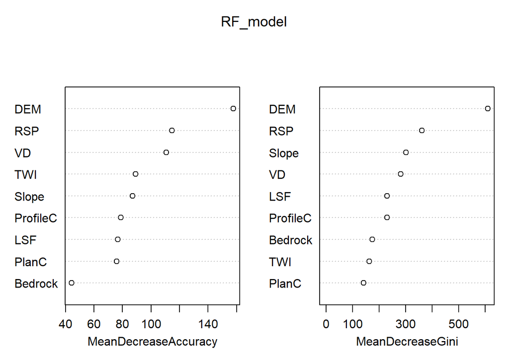

```r
sampleNum_dict[mn]<-nrow(sampData)

sampData$Bedrock<- droplevels(as.factor(sampData$Bedrock))
sampData$soilID<- droplevels(as.factor(sampData$soilID))

RF_model<-randomForest(soilID ~.,data = sampData,
                       importance = TRUE, proximity = FALSE,
                       ntree=1000,type="classification")

varImpPlot(RF_model)
```

```r
print(RF_model)
```

```
##
## Call:
##  randomForest(formula = soilID ~ ., data = sampData, importance = TRUE,      proximity = FALSE, ntree = 1000, type = "classification")
##                Type of random forest: classification
##                      Number of trees: 1000
## No. of variables tried at each split: 3
##
##         OOB estimate of  error rate: 18.56%
## Confusion matrix:
##      1  20 21  23   3 30  31 501 502 503   7 class.error
## 1   10   0  0   0   4  0   0   0   0   0   0  0.28571429
## 20   0 317 30   0   0  0   0   3   1  68  35  0.30176211
## 21   0  64 77   0   0  0   0   0   0  16   1  0.51265823
## 23   0   0  0 225   0  7  11   0   0  29   3  0.18181818
## 3    1   0  0   0 125  0   0  24   0   0   0  0.16666667
## 30   0   0  0  10   0 69   4   0   0   1   5  0.22471910
## 31   0   0  0   5   0  5 110   0   0   1   0  0.09090909
## 501  0   0  0   0  22  0   0 447   0   0  18  0.08213552
## 502  0   3  1   0   0  0   0   1  47   1   7  0.21666667
## 503  0  50  7  15   0  5   0   0   1 609  12  0.12875536
## 7    0  24  0   0   0  5   0  28   1  14 346  0.17224880
```

```r
map_RF <- predict(covStack, RF_model, paste(result_tif_folder,mn,".tif",sep=""),
                  format = "GTiff", datatype = "FLT4S", overwrite = TRUE)

rm("mn","shpPoint","sampData","RF_model","map_RF")
```

RAN PCA8 ns3 15

```r
mn="All_pRAN_PCA8_NS3_pen15"

shpPoint<-readOGR(paste(point_shp_folder,mn,".shp",sep = "")) ###
sampData <- extract(covStack, shpPoint, sp = TRUE,method = "simple")

sampData<-sampData@data

sampData<-sampData[sampData$soilID %in% soil_type,]

sampData<-na.omit(sampData)

print(dim(sampData))
```

```
## [1] 1003   10
```

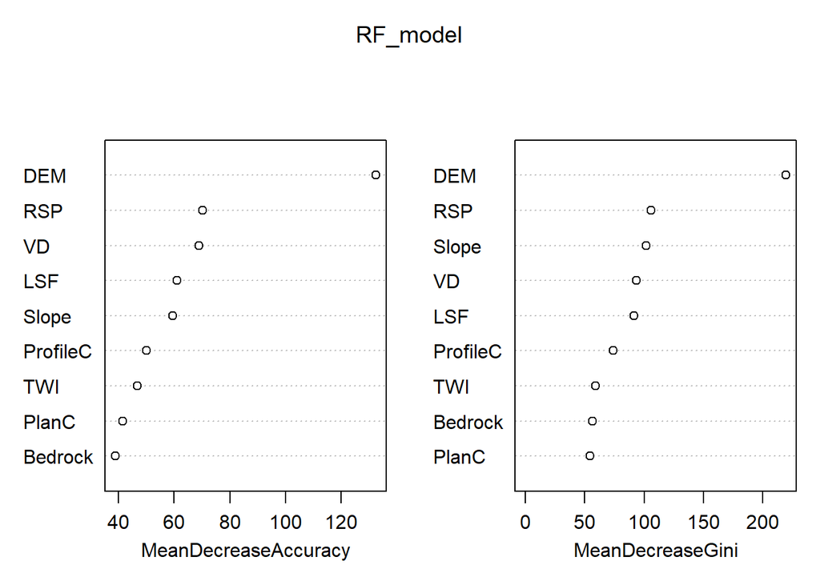

```r
sampleNum_dict[mn]<-nrow(sampData)

sampData$Bedrock<- droplevels(as.factor(sampData$Bedrock))
sampData$soilID<- droplevels(as.factor(sampData$soilID))

RF_model<-randomForest(soilID ~.,data = sampData,
                       importance = TRUE, proximity = FALSE,
                       ntree=1000,type="classification")

varImpPlot(RF_model)
```

```r
print(RF_model)
```

```
##
## Call:
##  randomForest(formula = soilID ~ ., data = sampData, importance = TRUE,      proximity = FALSE, ntree = 1000, type = "classification")
##                Type of random forest: classification
##                      Number of trees: 1000
## No. of variables tried at each split: 3
##
##         OOB estimate of  error rate: 26.12%
## Confusion matrix:
##     1  20 21 23  3 30 31 501 502 503   7 class.error
## 1   4   0  0  0  1  0  0   0   0   0   0  0.20000000
## 20  0 104 14  0  0  0  0   1   1  25  11  0.33333333
## 21  0  26 25  0  0  0  0   0   1   5   0  0.56140351
## 23  0   0  0 59  0 10  3   0   0  21   3  0.38541667
## 3   0   0  0  0 41  0  0   9   0   0   0  0.18000000
## 30  0   0  0  9  0 15  5   0   0   1   2  0.53125000
## 31  0   0  0  8  0  4 29   0   0   0   0  0.29268293
## 501 0   1  0  0  9  0  0 148   0   0   5  0.09202454
## 502 0   4  0  0  0  0  0   2  11   3   2  0.50000000
## 503 0  24  1  9  0  1  0   0   3 192   7  0.18987342
## 7   0  13  0  3  0  0  0   9   0   6 113  0.21527778
```

```r
map_RF <- predict(covStack, RF_model, paste(result_tif_folder,mn,".tif",sep=""),
                  format = "GTiff", datatype = "FLT4S", overwrite = TRUE)

rm("mn","shpPoint","sampData","RF_model","map_RF")
```

RAN PCA8 ns3 30

```r
mn="All_pRAN_PCA8_NS3_pen30"

shpPoint<-readOGR(paste(point_shp_folder,mn,".shp",sep = "")) ###
sampData <- extract(covStack, shpPoint, sp = TRUE,method = "simple")

sampData<-sampData@data

sampData<-sampData[sampData$soilID %in% soil_type,]

sampData<-na.omit(sampData)

print(dim(sampData))
```

```
## [1] 1965   10
```

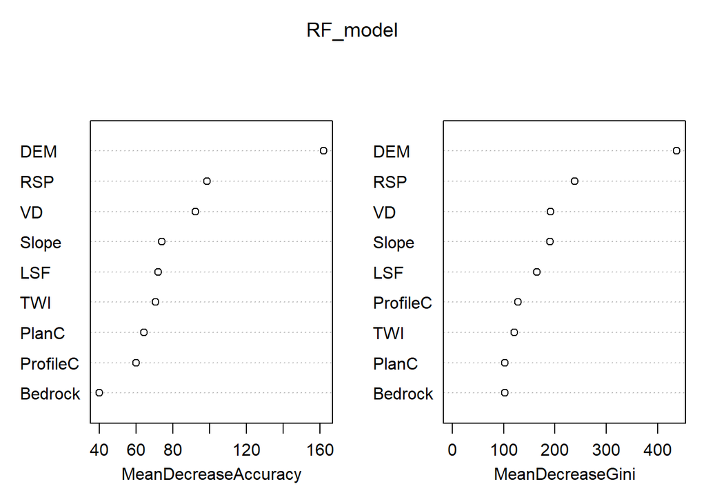

```r
sampleNum_dict[mn]<-nrow(sampData)

sampData$Bedrock<- droplevels(as.factor(sampData$Bedrock))
sampData$soilID<- droplevels(as.factor(sampData$soilID))

RF_model<-randomForest(soilID ~.,data = sampData,
                       importance = TRUE, proximity = FALSE,
                       ntree=1000,type="classification")

varImpPlot(RF_model)
```

```r
print(RF_model)
```

```
##
## Call:
##  randomForest(formula = soilID ~ ., data = sampData, importance = TRUE,      proximity = FALSE, ntree = 1000, type = "classification")
##                Type of random forest: classification
##                      Number of trees: 1000
## No. of variables tried at each split: 3
##
##         OOB estimate of  error rate: 22.65%
## Confusion matrix:
##     1  20 21  23  3 30 31 501 502 503   7 class.error
## 1   6   0  0   0  3  0  0   0   0   0   0  0.33333333
## 20  0 199 26   2  0  0  0   4   1  48  24  0.34539474
## 21  0  45 56   0  0  0  0   1   1   4   0  0.47663551
## 23  0   1  0 131  0 14  7   0   0  27   6  0.29569892
## 3   1   0  0   0 78  0  0  21   0   0   0  0.22000000
## 30  0   0  0  19  0 39  4   0   0   0   0  0.37096774
## 31  0   0  0   9  0  6 66   0   0   0   0  0.18518519
## 501 0   3  0   0 19  0  0 294   0   0   9  0.09538462
## 502 0   5  1   0  0  0  0   2  30   1   1  0.25000000
## 503 0  30  3  15  0  0  0   0   2 404  15  0.13859275
## 7   0  28  0   2  0  2  0  15   3  15 217  0.23049645
```

```r
map_RF <- predict(covStack, RF_model, paste(result_tif_folder,mn,".tif",sep=""),
                  format = "GTiff", datatype = "FLT4S", overwrite = TRUE)

rm("mn","shpPoint","sampData","RF_model","map_RF")
```

RAN PCA8 ns3 45

```r
mn="All_pRAN_PCA8_NS3_pen45"

shpPoint<-readOGR(paste(point_shp_folder,mn,".shp",sep = "")) ###
sampData <- extract(covStack, shpPoint, sp = TRUE,method = "simple")

sampData<-sampData@data

sampData<-sampData[sampData$soilID %in% soil_type,]

sampData<-na.omit(sampData)

print(dim(sampData))
```

```
## [1] 2925   10
```

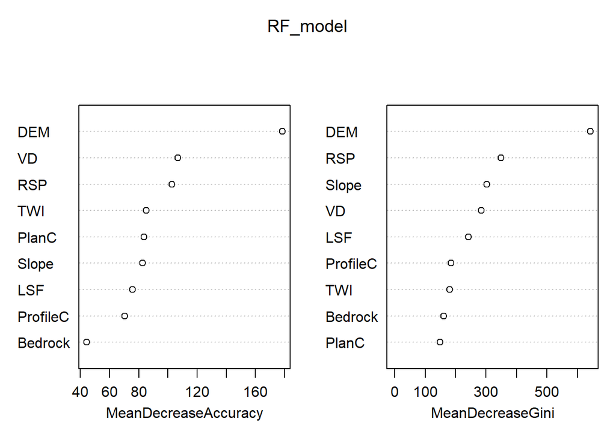

```r
sampleNum_dict[mn]<-nrow(sampData)

sampData$Bedrock<- droplevels(as.factor(sampData$Bedrock))
sampData$soilID<- droplevels(as.factor(sampData$soilID))

RF_model<-randomForest(soilID ~.,data = sampData,
                       importance = TRUE, proximity = FALSE,
                       ntree=1000,type="classification")

varImpPlot(RF_model)
```

```r
print(RF_model)
```

```
##
## Call:
##  randomForest(formula = soilID ~ ., data = sampData, importance = TRUE,      proximity = FALSE, ntree = 1000, type = "classification")
##                Type of random forest: classification
##                      Number of trees: 1000
## No. of variables tried at each split: 3
##
##         OOB estimate of  error rate: 19.76%
## Confusion matrix:
##      1  20 21  23   3 30  31 501 502 503   7 class.error
## 1   10   0  0   0   4  0   0   0   0   0   0  0.28571429
## 20   0 325 24   1   0  0   0   3   4  66  31  0.28414097
## 21   0  61 81   0   0  0   0   1   5   7   3  0.48734177
## 23   0   1  0 217   0 15   7   0   0  29   6  0.21090909
## 3    1   0  0   0 109  0   0  40   0   0   0  0.27333333
## 30   0   0  0  16   0 67   3   0   0   0   3  0.24719101
## 31   0   0  0  15   0  5 101   0   0   0   0  0.16528926
## 501  0   5  0   0  26  0   0 446   0   0  10  0.08418891
## 502  0   4  0   0   0  0   0   2  49   2   3  0.18333333
## 503  0  43  4  29   0  1   0   0   2 607  13  0.13161660
## 7    0  29  0   4   0  4   0  21   2  23 335  0.19856459
```

```r
map_RF <- predict(covStack, RF_model, paste(result_tif_folder,mn,".tif",sep=""),
                  format = "GTiff", datatype = "FLT4S", overwrite = TRUE)

rm("mn","shpPoint","sampData","RF_model","map_RF")
```

## ns5

SNA PCA8 ns5 15

```r
mn="All_pSNA_PCA8_NS5_pen15"

shpPoint<-readOGR(paste(point_shp_folder,mn,".shp",sep = "")) ###
sampData <- extract(covStack, shpPoint, sp = TRUE,method = "simple")

sampData<-sampData@data

sampData<-sampData[sampData$soilID %in% soil_type,]

sampData<-na.omit(sampData)

print(dim(sampData))
```

```
## [1] 359  10
```

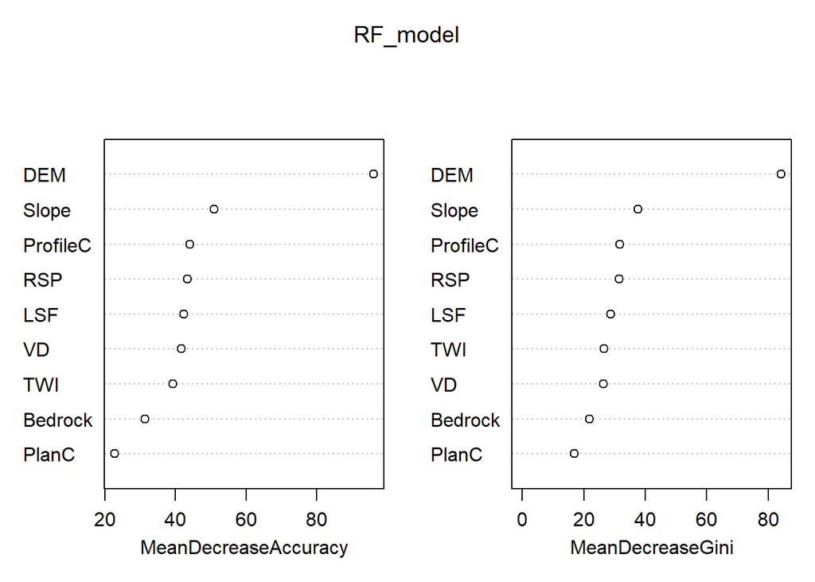

```r
sampleNum_dict[mn]<-nrow(sampData)

sampData$Bedrock<- droplevels(as.factor(sampData$Bedrock))
sampData$soilID<- droplevels(as.factor(sampData$soilID))

RF_model<-randomForest(soilID ~.,data = sampData,
                       importance = TRUE, proximity = FALSE,
                       ntree=1000,type="classification")

varImpPlot(RF_model)
```

```r
print(RF_model)
```

```
##
## Call:
##  randomForest(formula = soilID ~ ., data = sampData, importance = TRUE,      proximity = FALSE, ntree = 1000, type = "classification")
##                Type of random forest: classification
##                      Number of trees: 1000
## No. of variables tried at each split: 3
##
##         OOB estimate of  error rate: 25.07%
## Confusion matrix:
##     1 20 21 23  3 30 31 501 502 503  7 class.error
## 1   0  0  0  0  1  0  0   0   0   0  0  1.00000000
## 20  0 18  8  0  0  0  0   0   0  13  6  0.60000000
## 21  0 11  9  1  0  0  0   0   0   1  0  0.59090909
## 23  0  0  0 33  0  3  2   0   0   5  0  0.23255814
## 3   0  0  0  0 15  0  0   3   0   0  0  0.16666667
## 30  0  0  0  2  0  6  0   0   0   0  1  0.33333333
## 31  0  0  0  1  0  0 13   0   0   0  0  0.07142857
## 501 0  0  0  0  4  0  0  57   0   0  2  0.09523810
## 502 0  1  0  0  0  0  0   3   2   0  1  0.71428571
## 503 0  4  1  5  0  0  0   0   0  70  3  0.15662651
## 7   0  4  0  0  0  0  0   1   0   3 46  0.14814815
```

```r
map_RF <- predict(covStack, RF_model, paste(result_tif_folder,mn,".tif",sep=""),
                  format = "GTiff", datatype = "FLT4S", overwrite = TRUE)

rm("mn","shpPoint","sampData","RF_model","map_RF")
```

SNA PCA8 ns5 30

```r
mn="All_pSNA_PCA8_NS5_pen30"

shpPoint<-readOGR(paste(point_shp_folder,mn,".shp",sep = "")) ###
sampData <- extract(covStack, shpPoint, sp = TRUE,method = "simple")

sampData<-sampData@data

sampData<-sampData[sampData$soilID %in% soil_type,]

sampData<-na.omit(sampData)

print(dim(sampData))
```

```
## [1] 659  10
```

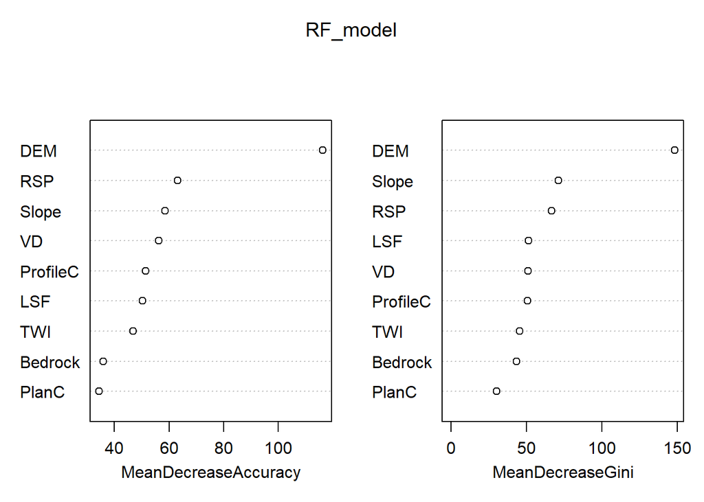

```r
sampleNum_dict[mn]<-nrow(sampData)

sampData$Bedrock<- droplevels(as.factor(sampData$Bedrock))
sampData$soilID<- droplevels(as.factor(sampData$soilID))

RF_model<-randomForest(soilID ~.,data = sampData,
                       importance = TRUE, proximity = FALSE,
                       ntree=1000,type="classification")

varImpPlot(RF_model)
```

```r
print(RF_model)
```

```
##
## Call:
##  randomForest(formula = soilID ~ ., data = sampData, importance = TRUE,      proximity = FALSE, ntree = 1000, type = "classification")
##                Type of random forest: classification
##                      Number of trees: 1000
## No. of variables tried at each split: 3
##
##         OOB estimate of  error rate: 20.18%
## Confusion matrix:
##     1 20 21 23  3 30 31 501 502 503  7 class.error
## 1   2  0  0  0  0  0  0   0   0   0  0  0.00000000
## 20  0 45  8  0  0  0  0   0   0  16 13  0.45121951
## 21  0 16 15  0  0  0  0   0   0   1  0  0.53125000
## 23  0  0  0 56  0  2  3   0   0   7  0  0.17647059
## 3   0  0  0  0 29  0  0   7   0   0  0  0.19444444
## 30  0  0  0  4  0 10  1   0   0   0  0  0.33333333
## 31  0  0  0  1  0  1 25   0   0   0  0  0.07407407
## 501 0  0  0  0  6  0  0 113   0   0  6  0.09600000
## 502 0  2  0  0  0  0  0   2   5   1  2  0.58333333
## 503 0  7  2  7  0  0  0   0   0 141  3  0.11875000
## 7   0  6  0  0  0  1  0   3   0   5 85  0.15000000
```

```r
map_RF <- predict(covStack, RF_model, paste(result_tif_folder,mn,".tif",sep=""),
                  format = "GTiff", datatype = "FLT4S", overwrite = TRUE)

rm("mn","shpPoint","sampData","RF_model","map_RF")
```

SNA PCA8 ns5 45

```r
mn="All_pSNA_PCA8_NS5_pen45"

shpPoint<-readOGR(paste(point_shp_folder,mn,".shp",sep = "")) ###
sampData <- extract(covStack, shpPoint, sp = TRUE,method = "simple")

sampData<-sampData@data

sampData<-sampData[sampData$soilID %in% soil_type,]

sampData<-na.omit(sampData)

print(dim(sampData))
```

```
## [1] 957  10
```

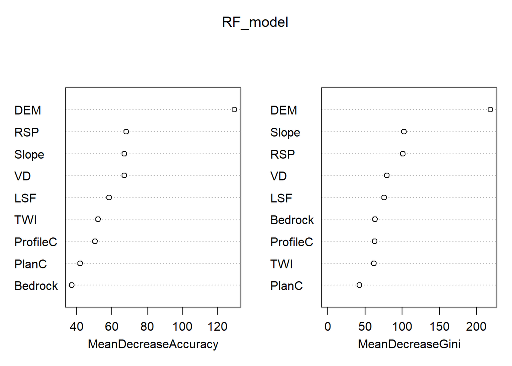

```r
sampleNum_dict[mn]<-nrow(sampData)

sampData$Bedrock<- droplevels(as.factor(sampData$Bedrock))
sampData$soilID<- droplevels(as.factor(sampData$soilID))

RF_model<-randomForest(soilID ~.,data = sampData,
                       importance = TRUE, proximity = FALSE,
                       ntree=1000,type="classification")

varImpPlot(RF_model)
```

```r
print(RF_model)
```

```
##
## Call:
##  randomForest(formula = soilID ~ ., data = sampData, importance = TRUE,      proximity = FALSE, ntree = 1000, type = "classification")
##                Type of random forest: classification
##                      Number of trees: 1000
## No. of variables tried at each split: 3
##
##         OOB estimate of  error rate: 18.7%
## Confusion matrix:
##     1 20 21 23  3 30 31 501 502 503   7 class.error
## 1   2  0  0  0  1  0  0   0   0   0   0  0.33333333
## 20  0 71 10  0  0  0  0   0   1  19  17  0.39830508
## 21  0 20 22  0  0  0  0   0   0   2   0  0.50000000
## 23  0  0  0 75  0  2  5   0   0  10   0  0.18478261
## 3   0  0  0  0 44  0  0  10   0   0   0  0.18518519
## 30  0  0  0  6  0 12  1   0   0   0   2  0.42857143
## 31  0  0  0  2  0  2 35   0   0   1   0  0.12500000
## 501 0  0  0  0  7  0  0 173   0   0   7  0.07486631
## 502 0  4  0  0  0  0  0   4   9   1   0  0.50000000
## 503 0 10  0  6  0  0  0   0   0 215   4  0.08510638
## 7   0 10  1  0  0  2  0   7   0   5 120  0.17241379
```

```r
map_RF <- predict(covStack, RF_model, paste(result_tif_folder,mn,".tif",sep=""),
                  format = "GTiff", datatype = "FLT4S", overwrite = TRUE)

rm("mn","shpPoint","sampData","RF_model","map_RF")
```

RAN PCA8 ns5 15

```r
mn="All_pRAN_PCA8_NS5_pen15"

shpPoint<-readOGR(paste(point_shp_folder,mn,".shp",sep = "")) ###
sampData <- extract(covStack, shpPoint, sp = TRUE,method = "simple")

sampData<-sampData@data

sampData<-sampData[sampData$soilID %in% soil_type,]

sampData<-na.omit(sampData)

print(dim(sampData))
```

```
## [1] 359  10
```

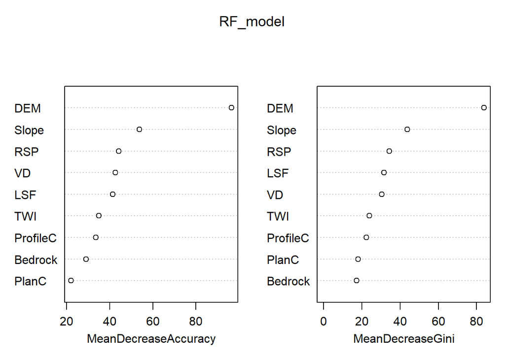

```r
sampleNum_dict[mn]<-nrow(sampData)

sampData$Bedrock<- droplevels(as.factor(sampData$Bedrock))
sampData$soilID<- droplevels(as.factor(sampData$soilID))

RF_model<-randomForest(soilID ~.,data = sampData,
                       importance = TRUE, proximity = FALSE,
                       ntree=1000,type="classification")

varImpPlot(RF_model)
```

```r
print(RF_model)
```

```
##
## Call:
##  randomForest(formula = soilID ~ ., data = sampData, importance = TRUE,      proximity = FALSE, ntree = 1000, type = "classification")
##                Type of random forest: classification
##                      Number of trees: 1000
## No. of variables tried at each split: 3
##
##         OOB estimate of  error rate: 25.63%
## Confusion matrix:
##     1 20 21 23  3 30 31 501 502 503  7 class.error
## 1   0  0  0  0  1  0  0   0   0   0  0   1.0000000
## 20  0 24  7  0  0  0  0   0   0   6  8   0.4666667
## 21  0  9 12  0  0  0  0   0   0   1  0   0.4545455
## 23  0  0  0 32  0  3  2   0   0   5  1   0.2558140
## 3   0  0  0  0 14  0  0   4   0   0  0   0.2222222
## 30  0  0  0  2  0  3  2   0   0   0  2   0.6666667
## 31  0  0  0  2  0  1 11   0   0   0  0   0.2142857
## 501 0  1  0  0  4  0  0  57   0   0  1   0.0952381
## 502 0  3  0  0  2  0  0   1   0   0  1   1.0000000
## 503 0  3  0  5  0  0  0   0   0  74  1   0.1084337
## 7   0  7  0  2  0  1  0   2   0   2 40   0.2592593
```

```r
map_RF <- predict(covStack, RF_model, paste(result_tif_folder,mn,".tif",sep=""),
                  format = "GTiff", datatype = "FLT4S", overwrite = TRUE)

rm("mn","shpPoint","sampData","RF_model","map_RF")
```

RAN PCA8 ns5 30

```r
mn="All_pRAN_PCA8_NS5_pen30"

shpPoint<-readOGR(paste(point_shp_folder,mn,".shp",sep = "")) ###
sampData <- extract(covStack, shpPoint, sp = TRUE,method = "simple")

sampData<-sampData@data

sampData<-sampData[sampData$soilID %in% soil_type,]

sampData<-na.omit(sampData)

print(dim(sampData))
```

```
## [1] 659  10
```

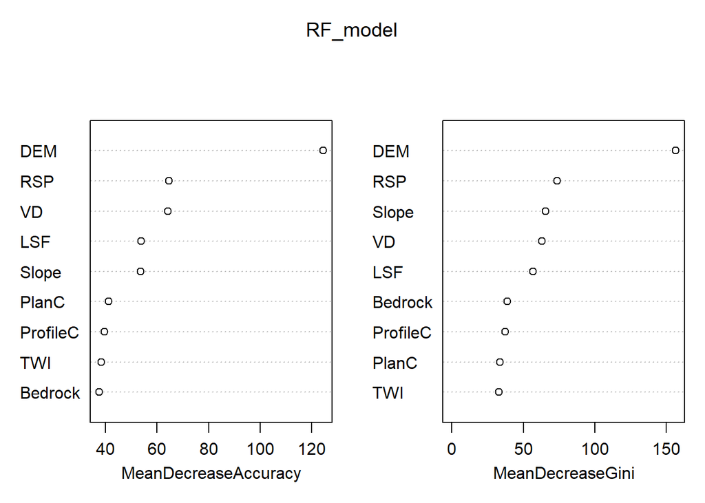

```r
sampleNum_dict[mn]<-nrow(sampData)

sampData$Bedrock<- droplevels(as.factor(sampData$Bedrock))
sampData$soilID<- droplevels(as.factor(sampData$soilID))

RF_model<-randomForest(soilID ~.,data = sampData,
                       importance = TRUE, proximity = FALSE,
                       ntree=1000,type="classification")

varImpPlot(RF_model)
```

```r
print(RF_model)
```

```
##
## Call:
##  randomForest(formula = soilID ~ ., data = sampData, importance = TRUE,      proximity = FALSE, ntree = 1000, type = "classification")
##                Type of random forest: classification
##                      Number of trees: 1000
## No. of variables tried at each split: 3
##
##         OOB estimate of  error rate: 20.49%
## Confusion matrix:
##     1 20 21 23  3 30 31 501 502 503  7 class.error
## 1   0  0  0  0  2  0  0   0   0   0  0   1.0000000
## 20  0 52  7  0  0  0  0   1   0  11 11   0.3658537
## 21  0 12 18  0  0  0  0   0   0   2  0   0.4375000
## 23  0  0  0 50  0  6  2   0   0   7  3   0.2647059
## 3   0  0  0  0 28  0  0   8   0   0  0   0.2222222
## 30  0  0  0  6  0  6  1   0   0   0  2   0.6000000
## 31  0  0  0  2  0  1 24   0   0   0  0   0.1111111
## 501 0  1  0  0  6  0  0 114   1   0  3   0.0880000
## 502 0  4  1  0  0  0  0   1   5   0  1   0.5833333
## 503 0  5  1  6  0  0  0   0   0 143  5   0.1062500
## 7   0  7  0  1  0  1  0   3   0   4 84   0.1600000
```

```r
map_RF <- predict(covStack, RF_model, paste(result_tif_folder,mn,".tif",sep=""),
                  format = "GTiff", datatype = "FLT4S", overwrite = TRUE)

rm("mn","shpPoint","sampData","RF_model","map_RF")
```

RAN PCA8 ns5 45

```r
mn="All_pRAN_PCA8_NS5_pen45"

shpPoint<-readOGR(paste(point_shp_folder,mn,".shp",sep = "")) ###
sampData <- extract(covStack, shpPoint, sp = TRUE,method = "simple")

sampData<-sampData@data

sampData<-sampData[sampData$soilID %in% soil_type,]

sampData<-na.omit(sampData)

print(dim(sampData))
```

```
## [1] 957  10
```

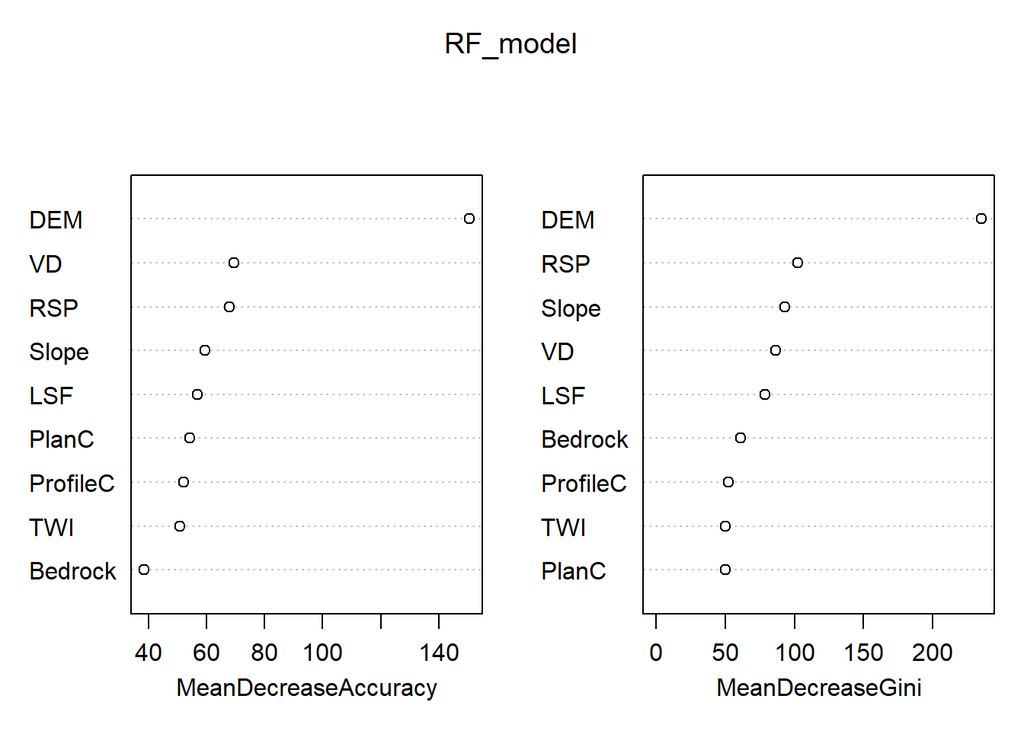

```r
sampleNum_dict[mn]<-nrow(sampData)

sampData$Bedrock<- droplevels(as.factor(sampData$Bedrock))
sampData$soilID<- droplevels(as.factor(sampData$soilID))

RF_model<-randomForest(soilID ~.,data = sampData,
                       importance = TRUE, proximity = FALSE,
                       ntree=1000,type="classification")

varImpPlot(RF_model)
```

```r
print(RF_model)
```

```
##
## Call:
##  randomForest(formula = soilID ~ ., data = sampData, importance = TRUE,      proximity = FALSE, ntree = 1000, type = "classification")
##                Type of random forest: classification
##                      Number of trees: 1000
## No. of variables tried at each split: 3
##
##         OOB estimate of  error rate: 16.93%
## Confusion matrix:
##     1 20 21 23  3 30 31 501 502 503   7 class.error
## 1   1  0  0  0  2  0  0   0   0   0   0   0.6666667
## 20  0 83  6  0  0  0  0   2   0  15  12   0.2966102
## 21  0 16 27  0  0  0  0   0   0   1   0   0.3863636
## 23  0  0  0 72  0  5  2   0   0  11   2   0.2173913
## 3   0  0  0  0 42  0  0  12   0   0   0   0.2222222
## 30  0  0  0  3  0 13  3   0   0   0   2   0.3809524
## 31  0  0  0  2  0  3 34   0   0   1   0   0.1500000
## 501 0  3  0  0 10  0  0 171   0   0   3   0.0855615
## 502 0  1  0  0  0  0  0   2  12   1   2   0.3333333
## 503 0  8  1  8  0  0  0   0   0 214   4   0.0893617
## 7   0 10  0  2  0  0  0   4   0   3 126   0.1310345
```

```r
map_RF <- predict(covStack, RF_model, paste(result_tif_folder,mn,".tif",sep=""),
                  format = "GTiff", datatype = "FLT4S", overwrite = TRUE)

rm("mn","shpPoint","sampData","RF_model","map_RF")
```

## ns7

SNA PCA8 ns7 15

```r
mn="All_pSNA_PCA8_NS7_pen15"

shpPoint<-readOGR(paste(point_shp_folder,mn,".shp",sep = "")) ###
sampData <- extract(covStack, shpPoint, sp = TRUE,method = "simple")

sampData<-sampData@data

sampData<-sampData[sampData$soilID %in% soil_type,]

sampData<-na.omit(sampData)

print(dim(sampData))
```

```
## [1] 136  10
```

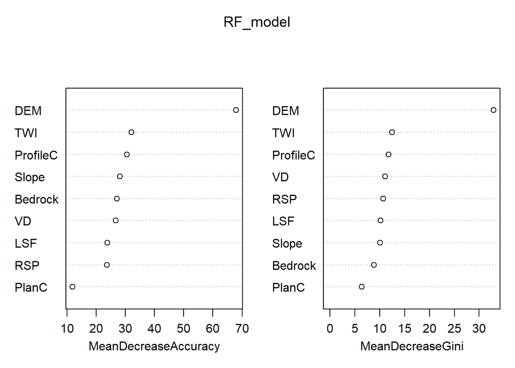

```r
sampleNum_dict[mn]<-nrow(sampData)

sampData$Bedrock<- droplevels(as.factor(sampData$Bedrock))
sampData$soilID<- droplevels(as.factor(sampData$soilID))

RF_model<-randomForest(soilID ~.,data = sampData,
                       importance = TRUE, proximity = FALSE,
                       ntree=1000,type="classification")

varImpPlot(RF_model)
```

```r
print(RF_model)
```

```
##
## Call:
##  randomForest(formula = soilID ~ ., data = sampData, importance = TRUE,      proximity = FALSE, ntree = 1000, type = "classification")
##                Type of random forest: classification
##                      Number of trees: 1000
## No. of variables tried at each split: 3
##
##         OOB estimate of  error rate: 23.53%
## Confusion matrix:
##     1 20 21 23 3 30 31 501 502 503  7 class.error
## 1   0  0  0  0 1  0  0   0   0   0  0  1.00000000
## 20  0  8  1  0 0  0  0   0   0   4  4  0.52941176
## 21  0  3  1  0 0  0  0   0   0   0  0  0.75000000
## 23  0  0  0 23 0  0  0   0   0   2  0  0.08000000
## 3   0  0  0  0 4  0  0   3   0   0  0  0.42857143
## 30  0  0  0  2 0  0  0   0   0   0  0  1.00000000
## 31  0  0  0  0 0  0  4   0   0   0  0  0.00000000
## 501 0  0  0  0 1  0  0  22   0   0  0  0.04347826
## 502 0  0  0  0 0  0  0   2   0   0  1  1.00000000
## 503 0  3  0  2 0  0  0   0   0  23  1  0.20689655
## 7   0  2  0  0 0  0  0   0   0   0 19  0.09523810
```

```r
map_RF <- predict(covStack, RF_model, paste(result_tif_folder,mn,".tif",sep=""),
                  format = "GTiff", datatype = "FLT4S", overwrite = TRUE)

rm("mn","shpPoint","sampData","RF_model","map_RF")
```

SNA PCA8 ns7 30

```r
mn="All_pSNA_PCA8_NS7_pen30"

shpPoint<-readOGR(paste(point_shp_folder,mn,".shp",sep = "")) ###
sampData <- extract(covStack, shpPoint, sp = TRUE,method = "simple")

sampData<-sampData@data

sampData<-sampData[sampData$soilID %in% soil_type,]

sampData<-na.omit(sampData)

print(dim(sampData))
```

```
## [1] 229  10
```

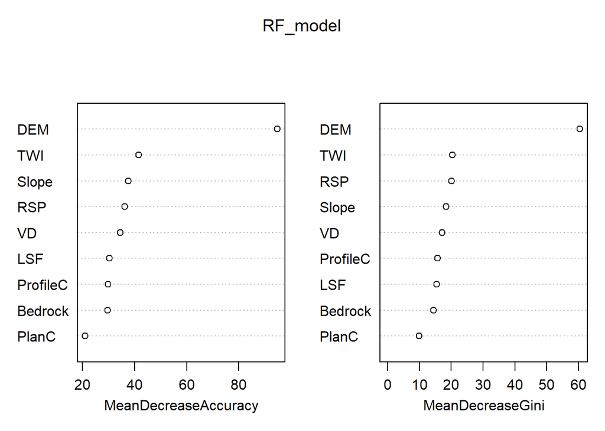

```r
sampleNum_dict[mn]<-nrow(sampData)

sampData$Bedrock<- droplevels(as.factor(sampData$Bedrock))
sampData$soilID<- droplevels(as.factor(sampData$soilID))

RF_model<-randomForest(soilID ~.,data = sampData,
                       importance = TRUE, proximity = FALSE,
                       ntree=1000,type="classification")

varImpPlot(RF_model)
```

```r
print(RF_model)
```

```
##
## Call:
##  randomForest(formula = soilID ~ ., data = sampData, importance = TRUE,      proximity = FALSE, ntree = 1000, type = "classification")
##                Type of random forest: classification
##                      Number of trees: 1000
## No. of variables tried at each split: 3
##
##         OOB estimate of  error rate: 20.09%
## Confusion matrix:
##     1 20 21 23  3 30 31 501 502 503  7 class.error
## 1   0  0  0  0  1  0  0   0   0   0  0  1.00000000
## 20  0 15  1  0  0  0  0   0   0   5  4  0.40000000
## 21  0  4  2  0  0  0  0   0   0   0  0  0.66666667
## 23  0  0  0 28  0  0  1   0   0   3  0  0.12500000
## 3   0  0  0  0 10  0  0   3   0   0  0  0.23076923
## 30  0  0  0  2  0  1  0   0   0   0  0  0.66666667
## 31  0  0  0  1  0  0  6   0   0   0  0  0.14285714
## 501 0  0  0  0  1  0  0  44   0   0  1  0.04347826
## 502 0  1  0  0  0  0  0   2   0   1  1  1.00000000
## 503 0  3  0  5  0  0  0   0   0  45  1  0.16666667
## 7   0  2  0  0  0  0  0   1   0   2 32  0.13513514
```

```r
map_RF <- predict(covStack, RF_model, paste(result_tif_folder,mn,".tif",sep=""),
                  format = "GTiff", datatype = "FLT4S", overwrite = TRUE)

rm("mn","shpPoint","sampData","RF_model","map_RF")
```

SNA PCA8 ns7 45

```r
mn="All_pSNA_PCA8_NS7_pen45"

shpPoint<-readOGR(paste(point_shp_folder,mn,".shp",sep = "")) ###
sampData <- extract(covStack, shpPoint, sp = TRUE,method = "simple")

sampData<-sampData@data

sampData<-sampData[sampData$soilID %in% soil_type,]

sampData<-na.omit(sampData)

print(dim(sampData))
```

```
## [1] 321  10
```

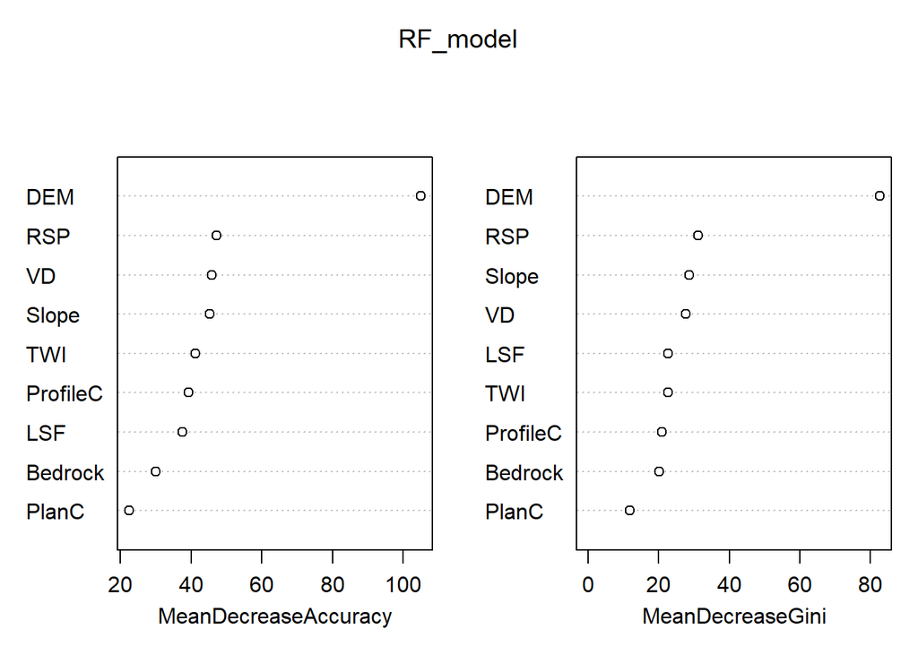

```r
sampleNum_dict[mn]<-nrow(sampData)

sampData$Bedrock<- droplevels(as.factor(sampData$Bedrock))
sampData$soilID<- droplevels(as.factor(sampData$soilID))

RF_model<-randomForest(soilID ~.,data = sampData,
                       importance = TRUE, proximity = FALSE,
                       ntree=1000,type="classification")

varImpPlot(RF_model)
```

```r
print(RF_model)
```

```
##
## Call:
##  randomForest(formula = soilID ~ ., data = sampData, importance = TRUE,      proximity = FALSE, ntree = 1000, type = "classification")
##                Type of random forest: classification
##                      Number of trees: 1000
## No. of variables tried at each split: 3
##
##         OOB estimate of  error rate: 16.82%
## Confusion matrix:
##     1 20 21 23  3 30 31 501 502 503  7 class.error
## 1   0  0  0  0  1  0  0   0   0   0  0  1.00000000
## 20  0 21  1  0  0  0  0   0   0   8  3  0.36363636
## 21  0  4  4  0  0  0  0   0   0   0  0  0.50000000
## 23  0  0  0 36  0  0  1   0   0   3  0  0.10000000
## 3   0  0  0  0 16  0  0   3   0   0  0  0.15789474
## 30  0  0  0  1  0  2  1   0   0   0  0  0.50000000
## 31  0  0  0  1  0  0 10   0   0   0  0  0.09090909
## 501 0  0  0  0  1  0  0  67   0   0  0  0.01470588
## 502 0  1  0  0  0  0  0   4   0   1  1  1.00000000
## 503 0  4  0  5  0  0  0   0   0  66  1  0.13157895
## 7   0  4  0  0  0  1  0   1   0   3 45  0.16666667
```

```r
map_RF <- predict(covStack, RF_model, paste(result_tif_folder,mn,".tif",sep=""),
                  format = "GTiff", datatype = "FLT4S", overwrite = TRUE)

rm("mn","shpPoint","sampData","RF_model","map_RF")
```

RAN PCA8 ns7 15

```r
mn="All_pRAN_PCA8_NS7_pen15"

shpPoint<-readOGR(paste(point_shp_folder,mn,".shp",sep = "")) ###
sampData <- extract(covStack, shpPoint, sp = TRUE,method = "simple")

sampData<-sampData@data

sampData<-sampData[sampData$soilID %in% soil_type,]

sampData<-na.omit(sampData)

print(dim(sampData))
```

```
## [1] 136  10
```

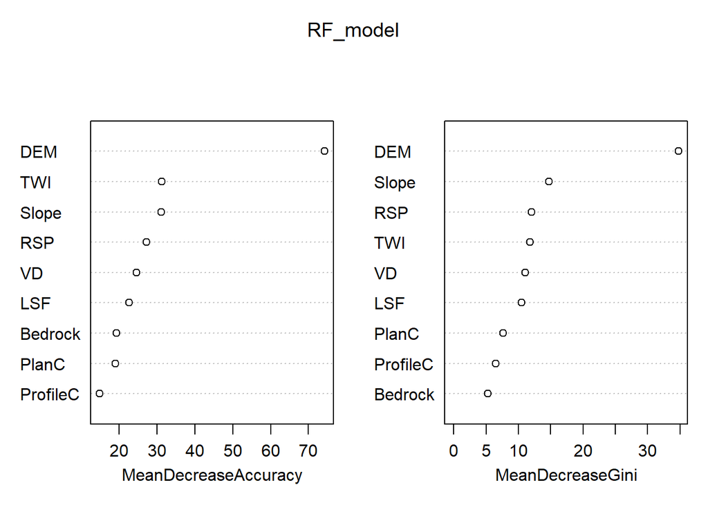

```r
sampleNum_dict[mn]<-nrow(sampData)

sampData$Bedrock<- droplevels(as.factor(sampData$Bedrock))
sampData$soilID<- droplevels(as.factor(sampData$soilID))

RF_model<-randomForest(soilID ~.,data = sampData,
                       importance = TRUE, proximity = FALSE,
                       ntree=1000,type="classification")

varImpPlot(RF_model)
```

```r
print(RF_model)
```

```
##
## Call:
##  randomForest(formula = soilID ~ ., data = sampData, importance = TRUE,      proximity = FALSE, ntree = 1000, type = "classification")
##                Type of random forest: classification
##                      Number of trees: 1000
## No. of variables tried at each split: 3
##
##         OOB estimate of  error rate: 23.53%
## Confusion matrix:
##     1 20 21 23 3 30 31 501 502 503  7 class.error
## 1   0  0  0  0 1  0  0   0   0   0  0   1.0000000
## 20  0 10  0  0 0  0  0   0   0   3  4   0.4117647
## 21  0  3  1  0 0  0  0   0   0   0  0   0.7500000
## 23  0  0  0 22 0  1  0   0   0   1  1   0.1200000
## 3   1  0  0  0 4  0  0   2   0   0  0   0.4285714
## 30  0  0  0  2 0  0  0   0   0   0  0   1.0000000
## 31  0  0  0  0 0  0  4   0   0   0  0   0.0000000
## 501 0  0  0  0 0  0  0  23   0   0  0   0.0000000
## 502 0  1  1  0 1  0  0   0   0   0  0   1.0000000
## 503 0  2  0  2 0  0  0   0   0  24  1   0.1724138
## 7   0  3  0  1 0  0  0   0   0   1 16   0.2380952
```

```r
map_RF <- predict(covStack, RF_model, paste(result_tif_folder,mn,".tif",sep=""),
                  format = "GTiff", datatype = "FLT4S", overwrite = TRUE)

rm("mn","shpPoint","sampData","RF_model","map_RF")
```

RAN PCA8 ns7 30

```r
mn="All_pRAN_PCA8_NS7_pen30"

shpPoint<-readOGR(paste(point_shp_folder,mn,".shp",sep = "")) ###
sampData <- extract(covStack, shpPoint, sp = TRUE,method = "simple")

sampData<-sampData@data

sampData<-sampData[sampData$soilID %in% soil_type,]

sampData<-na.omit(sampData)

print(dim(sampData))
```

```
## [1] 229  10
```

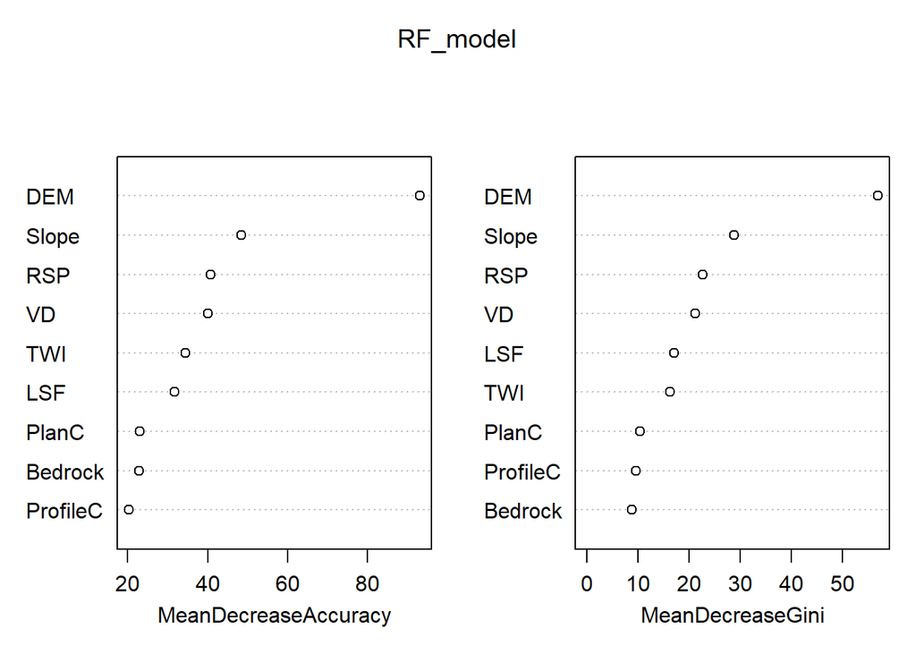

```r
sampleNum_dict[mn]<-nrow(sampData)

sampData$Bedrock<- droplevels(as.factor(sampData$Bedrock))
sampData$soilID<- droplevels(as.factor(sampData$soilID))

RF_model<-randomForest(soilID ~.,data = sampData,
                       importance = TRUE, proximity = FALSE,
                       ntree=1000,type="classification")

varImpPlot(RF_model)
```

```r
print(RF_model)
```

```
##
## Call:
##  randomForest(formula = soilID ~ ., data = sampData, importance = TRUE,      proximity = FALSE, ntree = 1000, type = "classification")
##                Type of random forest: classification
##                      Number of trees: 1000
## No. of variables tried at each split: 3
##
##         OOB estimate of  error rate: 20.09%
## Confusion matrix:
##     1 20 21 23  3 30 31 501 502 503  7 class.error
## 1   0  0  0  0  1  0  0   0   0   0  0  1.00000000
## 20  0 18  0  0  0  0  0   0   0   3  4  0.28000000
## 21  0  3  2  0  0  0  0   0   1   0  0  0.66666667
## 23  0  0  0 25  0  3  0   0   0   4  0  0.21875000
## 3   0  0  0  0 12  0  0   1   0   0  0  0.07692308
## 30  0  0  0  3  0  0  0   0   0   0  0  1.00000000
## 31  0  0  0  1  0  0  6   0   0   0  0  0.14285714
## 501 0  0  0  0  1  0  0  45   0   0  0  0.02173913
## 502 0  1  0  0  1  0  0   1   0   1  1  1.00000000
## 503 0  2  0  5  0  0  0   0   0  46  1  0.14814815
## 7   0  3  0  0  0  0  0   2   0   3 29  0.21621622
```

```r
map_RF <- predict(covStack, RF_model, paste(result_tif_folder,mn,".tif",sep=""),
                  format = "GTiff", datatype = "FLT4S", overwrite = TRUE)

rm("mn","shpPoint","sampData","RF_model","map_RF")
```

RAN PCA8 ns7 45

```r
mn="All_pRAN_PCA8_NS7_pen45"

shpPoint<-readOGR(paste(point_shp_folder,mn,".shp",sep = "")) ###
sampData <- extract(covStack, shpPoint, sp = TRUE,method = "simple")

sampData<-sampData@data

sampData<-sampData[sampData$soilID %in% soil_type,]

sampData<-na.omit(sampData)

print(dim(sampData))
```

```
## [1] 321  10
```

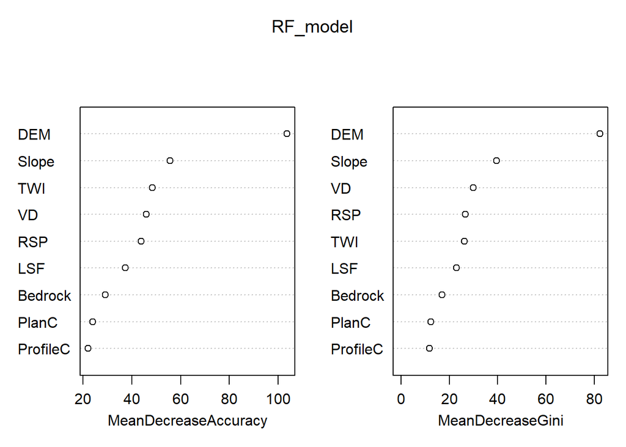

```r
sampleNum_dict[mn]<-nrow(sampData)

sampData$Bedrock<- droplevels(as.factor(sampData$Bedrock))
sampData$soilID<- droplevels(as.factor(sampData$soilID))

RF_model<-randomForest(soilID ~.,data = sampData,
                       importance = TRUE, proximity = FALSE,
                       ntree=1000,type="classification")

varImpPlot(RF_model)
```

```r
print(RF_model)
```

```
##
## Call:
##  randomForest(formula = soilID ~ ., data = sampData, importance = TRUE,      proximity = FALSE, ntree = 1000, type = "classification")
##                Type of random forest: classification
##                      Number of trees: 1000
## No. of variables tried at each split: 3
##
##         OOB estimate of  error rate: 16.82%
## Confusion matrix:
##     1 20 21 23  3 30 31 501 502 503  7 class.error
## 1   0  0  0  0  1  0  0   0   0   0  0  1.00000000
## 20  0 23  2  0  0  0  0   0   0   3  5  0.30303030
## 21  0  3  5  0  0  0  0   0   0   0  0  0.37500000
## 23  0  0  0 32  0  4  1   0   0   3  0  0.20000000
## 3   0  0  0  0 14  0  0   5   0   0  0  0.26315789
## 30  0  0  0  4  0  0  0   0   0   0  0  1.00000000
## 31  0  0  0  1  0  0 10   0   0   0  0  0.09090909
## 501 0  0  0  0  1  0  0  65   1   0  1  0.04411765
## 502 0  3  0  0  0  0  0   1   3   0  0  0.57142857
## 503 0  1  0  3  0  0  0   0   0  70  2  0.07894737
## 7   0  2  0  0  0  0  0   3   0   4 45  0.16666667
```

```r
map_RF <- predict(covStack, RF_model, paste(result_tif_folder,mn,".tif",sep=""),
                  format = "GTiff", datatype = "FLT4S", overwrite = TRUE)

rm("mn","shpPoint","sampData","RF_model","map_RF")
```

# PCA6 -ok

## ns3

SNA PCA6 ns3 15

```r
mn="All_pSNA_PCA6_NS3_pen15"

shpPoint<-readOGR(paste(point_shp_folder,mn,".shp",sep = "")) ###
sampData <- extract(covStack, shpPoint, sp = TRUE,method = "simple")

sampData<-sampData@data

sampData<-sampData[sampData$soilID %in% soil_type,]

sampData<-na.omit(sampData)

print(dim(sampData))
```

```
## [1] 989  10
```

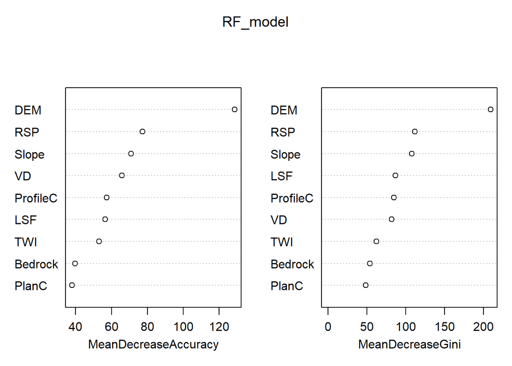

```r
sampleNum_dict[mn]<-nrow(sampData)

sampData$Bedrock<- droplevels(as.factor(sampData$Bedrock))
sampData$soilID<- droplevels(as.factor(sampData$soilID))

RF_model<-randomForest(soilID ~.,data = sampData,
                       importance = TRUE, proximity = FALSE,
                       ntree=1000,type="classification")

varImpPlot(RF_model)
```

```r
print(RF_model)
```

```
##
## Call:
##  randomForest(formula = soilID ~ ., data = sampData, importance = TRUE,      proximity = FALSE, ntree = 1000, type = "classification")
##                Type of random forest: classification
##                      Number of trees: 1000
## No. of variables tried at each split: 3
##
##         OOB estimate of  error rate: 22.35%
## Confusion matrix:
##     1 20 21 23  3 30 31 501 502 503   7 class.error
## 1   2  0  0  0  3  0  0   0   0   0   0  0.60000000
## 20  0 87  9  0  0  0  0   2   0  38  18  0.43506494
## 21  0 20 32  0  0  0  0   0   0   7   0  0.45762712
## 23  0  0  0 77  0  3  3   0   0   9   3  0.18947368
## 3   0  0  0  0 42  0  0   8   0   0   0  0.16000000
## 30  0  0  0  6  0 25  0   0   0   0   1  0.21875000
## 31  0  0  0  1  0  0 41   0   0   0   0  0.02380952
## 501 0  0  0  0  8  0  0 146   0   0   5  0.08176101
## 502 0  2  0  0  0  0  0   2  16   0   1  0.23809524
## 503 0 21  3 12  0  0  0   0   0 193   2  0.16450216
## 7   0 15  0  1  0  2  0  10   0   6 107  0.24113475
```

```r
map_RF <- predict(covStack, RF_model, paste(result_tif_folder,mn,".tif",sep=""),
                  format = "GTiff", datatype = "FLT4S", overwrite = TRUE)

rm("mn","shpPoint","sampData","RF_model","map_RF")
```

SNA PCA6 ns3 30

```r
mn="All_pSNA_PCA6_NS3_pen30"

shpPoint<-readOGR(paste(point_shp_folder,mn,".shp",sep = "")) ###
sampData <- extract(covStack, shpPoint, sp = TRUE,method = "simple")

sampData<-sampData@data

sampData<-sampData[sampData$soilID %in% soil_type,]

sampData<-na.omit(sampData)

print(dim(sampData))
```

```
## [1] 1940   10
```

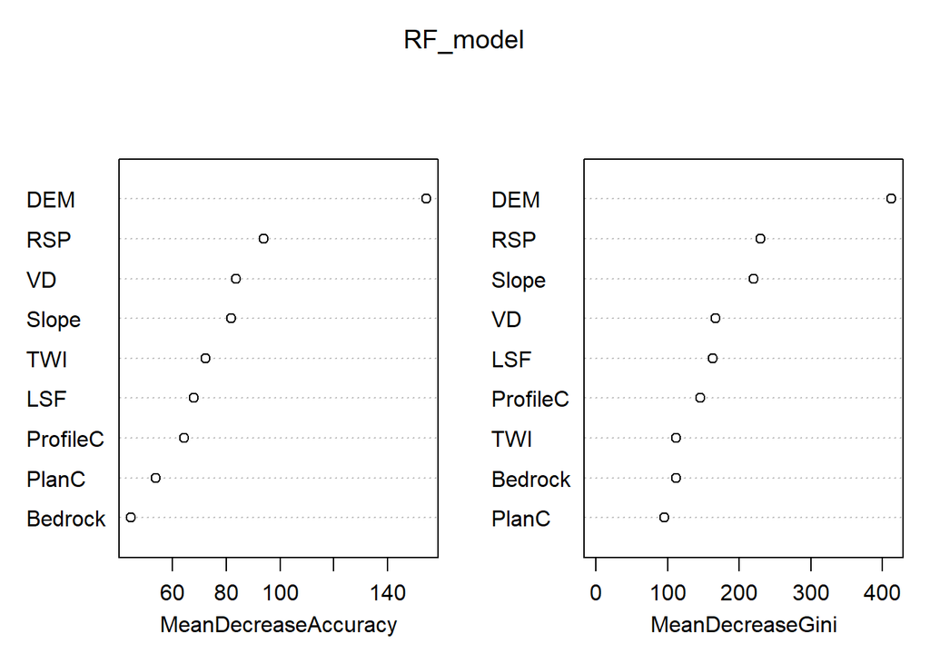

```r
sampleNum_dict[mn]<-nrow(sampData)

sampData$Bedrock<- droplevels(as.factor(sampData$Bedrock))
sampData$soilID<- droplevels(as.factor(sampData$soilID))

RF_model<-randomForest(soilID ~.,data = sampData,
                       importance = TRUE, proximity = FALSE,
                       ntree=1000,type="classification")

varImpPlot(RF_model)
```

```r
print(RF_model)
```

```
##
## Call:
##  randomForest(formula = soilID ~ ., data = sampData, importance = TRUE,      proximity = FALSE, ntree = 1000, type = "classification")
##                Type of random forest: classification
##                      Number of trees: 1000
## No. of variables tried at each split: 3
##
##         OOB estimate of  error rate: 20.72%
## Confusion matrix:
##     1  20 21  23  3 30 31 501 502 503   7 class.error
## 1   5   0  0   0  4  0  0   0   0   0   0  0.44444444
## 20  0 177 30   0  0  0  0   2   0  60  31  0.41000000
## 21  0  42 55   0  0  0  0   0   1  12   1  0.50450450
## 23  0   0  0 158  0  5  5   0   0  14   4  0.15053763
## 3   1   0  0   0 90  0  0   9   0   0   0  0.10000000
## 30  0   0  0   9  0 46  2   0   0   0   4  0.24590164
## 31  0   0  0   6  0  1 76   0   0   0   0  0.08433735
## 501 0   0  0   0 15  0  0 288   0   0  14  0.09148265
## 502 0   2  0   0  0  0  0   3  29   1   5  0.27500000
## 503 0  36  3  20  0  1  0   0   1 389   7  0.14879650
## 7   0  19  0   0  0  3  0  19   0  10 225  0.18478261
```

```r
map_RF <- predict(covStack, RF_model, paste(result_tif_folder,mn,".tif",sep=""),
                  format = "GTiff", datatype = "FLT4S", overwrite = TRUE)

rm("mn","shpPoint","sampData","RF_model","map_RF")
```

SNA PCA6 ns3 45

```r
mn="All_pSNA_PCA6_NS3_pen45"

shpPoint<-readOGR(paste(point_shp_folder,mn,".shp",sep = "")) ###
sampData <- extract(covStack, shpPoint, sp = TRUE,method = "simple")

sampData<-sampData@data

sampData<-sampData[sampData$soilID %in% soil_type,]

sampData<-na.omit(sampData)

print(dim(sampData))
```

```
## [1] 2882   10
```

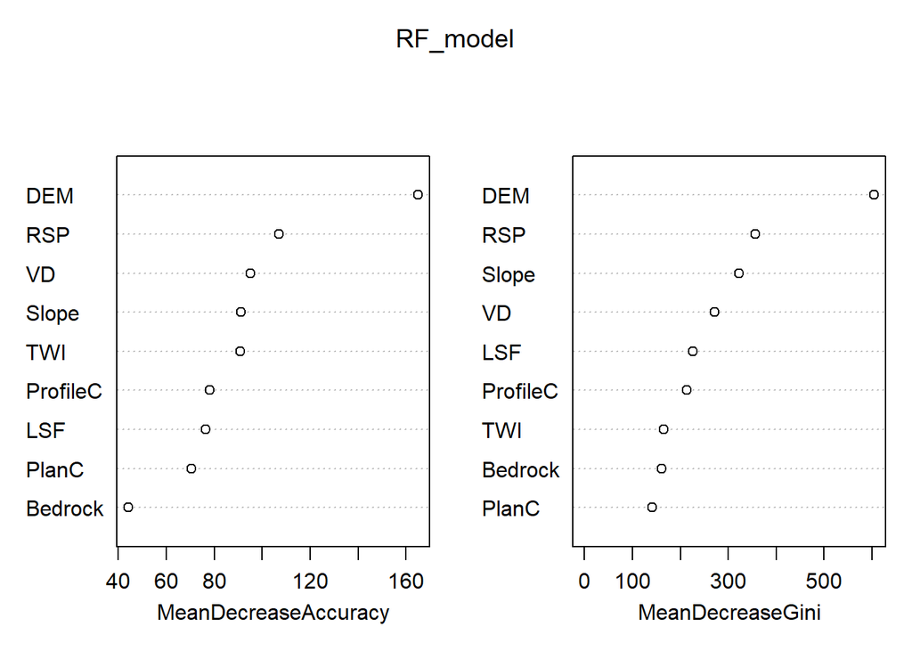

```r
sampleNum_dict[mn]<-nrow(sampData)

sampData$Bedrock<- droplevels(as.factor(sampData$Bedrock))
sampData$soilID<- droplevels(as.factor(sampData$soilID))

RF_model<-randomForest(soilID ~.,data = sampData,
                       importance = TRUE, proximity = FALSE,
                       ntree=1000,type="classification")

varImpPlot(RF_model)
```

```r
print(RF_model)
```

```
##
## Call:
##  randomForest(formula = soilID ~ ., data = sampData, importance = TRUE,      proximity = FALSE, ntree = 1000, type = "classification")
##                Type of random forest: classification
##                      Number of trees: 1000
## No. of variables tried at each split: 3
##
##         OOB estimate of  error rate: 20.19%
## Confusion matrix:
##      1  20 21  23   3 30  31 501 502 503   7 class.error
## 1   10   0  0   0   4  0   0   0   0   0   0  0.28571429
## 20   0 296 31   0   0  0   0   4   0  76  38  0.33483146
## 21   0  58 86   0   0  0   0   1   1  16   0  0.46913580
## 23   0   0  0 237   0  6   8   0   0  21   3  0.13818182
## 3    2   0  0   0 119  0   0  27   0   0   0  0.19594595
## 30   0   0  0  12   0 69   3   0   0   0   5  0.22471910
## 31   0   0  0   6   0  4 113   0   0   1   0  0.08870968
## 501  0   2  0   0  31  0   0 421   2   0  19  0.11368421
## 502  0   4  0   0   0  0   0   4  42   2   8  0.30000000
## 503  0  63  4  24   0  3   0   0   1 574  12  0.15712188
## 7    0  27  0   1   0  6   0  25   1  16 333  0.18581907
```

```r
map_RF <- predict(covStack, RF_model, paste(result_tif_folder,mn,".tif",sep=""),
                  format = "GTiff", datatype = "FLT4S", overwrite = TRUE)

rm("mn","shpPoint","sampData","RF_model","map_RF")
```

RAN PCA6 ns3 15

```r
mn="All_pRAN_PCA6_NS3_pen15"

shpPoint<-readOGR(paste(point_shp_folder,mn,".shp",sep = "")) ###
sampData <- extract(covStack, shpPoint, sp = TRUE,method = "simple")

sampData<-sampData@data

sampData<-sampData[sampData$soilID %in% soil_type,]

sampData<-na.omit(sampData)

print(dim(sampData))
```

```
## [1] 989  10
```

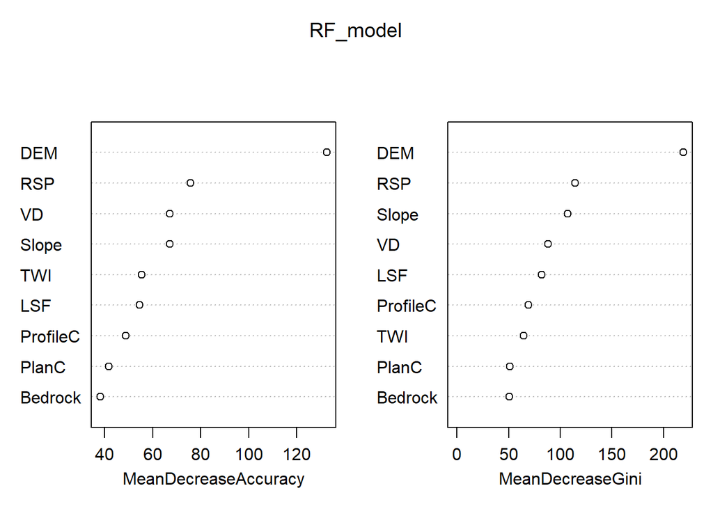

```r
sampleNum_dict[mn]<-nrow(sampData)

sampData$Bedrock<- droplevels(as.factor(sampData$Bedrock))
sampData$soilID<- droplevels(as.factor(sampData$soilID))

RF_model<-randomForest(soilID ~.,data = sampData,
                       importance = TRUE, proximity = FALSE,
                       ntree=1000,type="classification")

varImpPlot(RF_model)
```

```r
print(RF_model)
```

```
##
## Call:
##  randomForest(formula = soilID ~ ., data = sampData, importance = TRUE,      proximity = FALSE, ntree = 1000, type = "classification")
##                Type of random forest: classification
##                      Number of trees: 1000
## No. of variables tried at each split: 3
##
##         OOB estimate of  error rate: 25.18%
## Confusion matrix:
##     1  20 21 23  3 30 31 501 502 503   7 class.error
## 1   3   0  0  0  2  0  0   0   0   0   0  0.40000000
## 20  0 100 18  0  0  0  0   0   2  19  15  0.35064935
## 21  0  30 19  0  0  0  0   1   1   7   1  0.67796610
## 23  0   0  0 66  0  7  4   0   0  13   5  0.30526316
## 3   0   0  0  0 41  0  0   9   0   0   0  0.18000000
## 30  0   0  0  5  0 18  5   0   0   0   4  0.43750000
## 31  0   0  0  7  0  2 33   0   0   0   0  0.21428571
## 501 0   0  0  0  5  0  0 151   0   0   3  0.05031447
## 502 0   6  1  0  0  0  0   3  11   0   0  0.47619048
## 503 0  17  2 12  0  0  0   0   0 193   7  0.16450216
## 7   0  16  1  1  0  1  0   7   0  10 105  0.25531915
```

```r
map_RF <- predict(covStack, RF_model, paste(result_tif_folder,mn,".tif",sep=""),
                  format = "GTiff", datatype = "FLT4S", overwrite = TRUE)

rm("mn","shpPoint","sampData","RF_model","map_RF")
```

RAN PCA6 ns3 30

```r
mn="All_pRAN_PCA6_NS3_pen30"

shpPoint<-readOGR(paste(point_shp_folder,mn,".shp",sep = "")) ###
sampData <- extract(covStack, shpPoint, sp = TRUE,method = "simple")

sampData<-sampData@data

sampData<-sampData[sampData$soilID %in% soil_type,]

sampData<-na.omit(sampData)

print(dim(sampData))
```

```
## [1] 1940   10
```

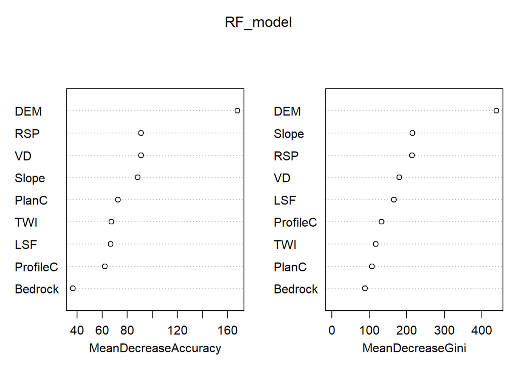

```r
sampleNum_dict[mn]<-nrow(sampData)

sampData$Bedrock<- droplevels(as.factor(sampData$Bedrock))
sampData$soilID<- droplevels(as.factor(sampData$soilID))

RF_model<-randomForest(soilID ~.,data = sampData,
                       importance = TRUE, proximity = FALSE,
                       ntree=1000,type="classification")

varImpPlot(RF_model)
```

```r
print(RF_model)
```

```
##
## Call:
##  randomForest(formula = soilID ~ ., data = sampData, importance = TRUE,      proximity = FALSE, ntree = 1000, type = "classification")
##                Type of random forest: classification
##                      Number of trees: 1000
## No. of variables tried at each split: 3
##
##         OOB estimate of  error rate: 22.22%
## Confusion matrix:
##     1  20 21  23  3 30 31 501 502 503   7 class.error
## 1   6   0  0   0  3  0  0   0   0   0   0   0.3333333
## 20  0 209 28   1  0  0  0   3   1  39  19   0.3033333
## 21  0  41 60   0  0  0  0   0   3   7   0   0.4594595
## 23  0   2  0 131  0 13 11   0   0  22   7   0.2956989
## 3   2   0  0   0 73  0  0  25   0   0   0   0.2700000
## 30  0   0  0  15  0 36  5   0   0   0   5   0.4098361
## 31  0   0  0   7  0  6 70   0   0   0   0   0.1566265
## 501 0   3  1   0 26  0  0 277   2   0   8   0.1261830
## 502 0   5  3   0  0  0  0   1  29   0   2   0.2750000
## 503 0  32  3  17  0  0  0   0   0 396   9   0.1334792
## 7   0  24  1   2  0  3  0  10   1  13 222   0.1956522
```

```r
map_RF <- predict(covStack, RF_model, paste(result_tif_folder,mn,".tif",sep=""),
                  format = "GTiff", datatype = "FLT4S", overwrite = TRUE)

rm("mn","shpPoint","sampData","RF_model","map_RF")
```

RAN PCA6 ns3 45

```r
mn="All_pRAN_PCA6_NS3_pen45"

shpPoint<-readOGR(paste(point_shp_folder,mn,".shp",sep = "")) ###
sampData <- extract(covStack, shpPoint, sp = TRUE,method = "simple")

sampData<-sampData@data

sampData<-sampData[sampData$soilID %in% soil_type,]

sampData<-na.omit(sampData)

print(dim(sampData))
```

```
## [1] 2882   10
```

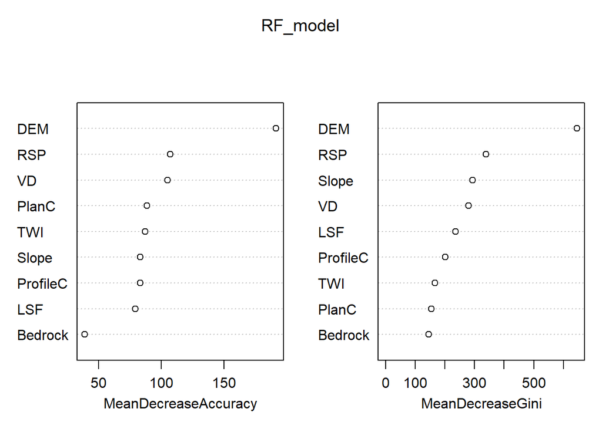

```r
sampleNum_dict[mn]<-nrow(sampData)

sampData$Bedrock<- droplevels(as.factor(sampData$Bedrock))
sampData$soilID<- droplevels(as.factor(sampData$soilID))

RF_model<-randomForest(soilID ~.,data = sampData,
                       importance = TRUE, proximity = FALSE,
                       ntree=1000,type="classification")

varImpPlot(RF_model)
```

```r
print(RF_model)
```

```
##
## Call:
##  randomForest(formula = soilID ~ ., data = sampData, importance = TRUE,      proximity = FALSE, ntree = 1000, type = "classification")
##                Type of random forest: classification
##                      Number of trees: 1000
## No. of variables tried at each split: 3
##
##         OOB estimate of  error rate: 17.73%
## Confusion matrix:
##      1  20  21  23   3 30  31 501 502 503   7 class.error
## 1   11   0   0   0   3  0   0   0   0   0   0  0.21428571
## 20   0 323  31   0   0  0   0   2   2  56  31  0.27415730
## 21   0  49 103   0   0  0   0   1   1   8   0  0.36419753
## 23   0   0   0 210   0 16   8   0   0  30  11  0.23636364
## 3    3   0   0   0 119  0   0  26   0   0   0  0.19594595
## 30   0   0   0  14   0 65   4   0   0   1   5  0.26966292
## 31   0   0   0   9   0  5 110   0   0   0   0  0.11290323
## 501  0   2   0   0  21  0   0 443   2   0   7  0.06736842
## 502  0   4   1   0   0  0   0   1  49   1   4  0.18333333
## 503  0  39   6  23   0  1   0   0   0 603   9  0.11453744
## 7    0  26   1   2   0  5   0  20   4  16 335  0.18092910
```

```r
map_RF <- predict(covStack, RF_model, paste(result_tif_folder,mn,".tif",sep=""),
                  format = "GTiff", datatype = "FLT4S", overwrite = TRUE)

rm("mn","shpPoint","sampData","RF_model","map_RF")
```

## ns5

SNA PCA6 ns5 15

```r
mn="All_pSNA_PCA6_NS5_pen15"

shpPoint<-readOGR(paste(point_shp_folder,mn,".shp",sep = "")) ###
sampData <- extract(covStack, shpPoint, sp = TRUE,method = "simple")

sampData<-sampData@data

sampData<-sampData[sampData$soilID %in% soil_type,]

sampData<-na.omit(sampData)

print(dim(sampData))
```

```
## [1] 354  10
```

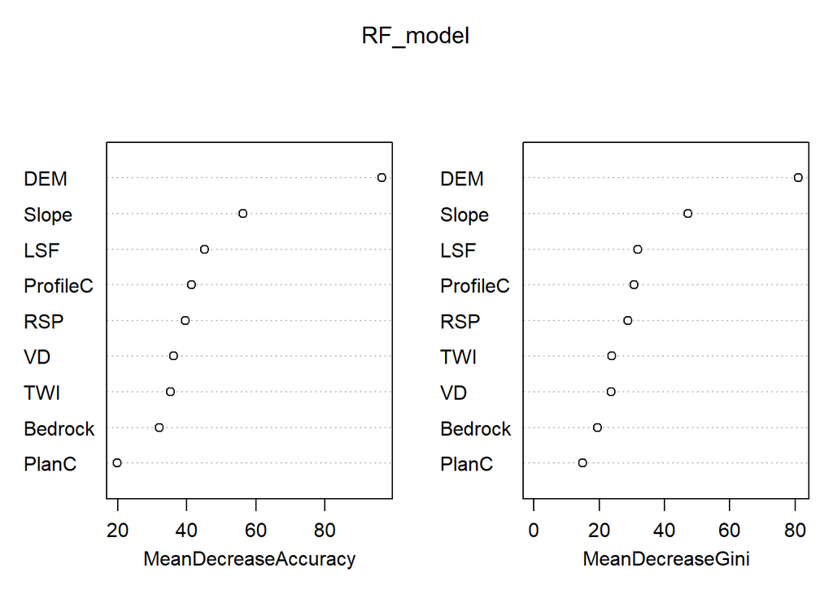

```r
sampleNum_dict[mn]<-nrow(sampData)

sampData$Bedrock<- droplevels(as.factor(sampData$Bedrock))
sampData$soilID<- droplevels(as.factor(sampData$soilID))

RF_model<-randomForest(soilID ~.,data = sampData,
                       importance = TRUE, proximity = FALSE,
                       ntree=1000,type="classification")

varImpPlot(RF_model)
```

```r
print(RF_model)
```

```
##
## Call:
##  randomForest(formula = soilID ~ ., data = sampData, importance = TRUE,      proximity = FALSE, ntree = 1000, type = "classification")
##                Type of random forest: classification
##                      Number of trees: 1000
## No. of variables tried at each split: 3
##
##         OOB estimate of  error rate: 23.73%
## Confusion matrix:
##     1 20 21 23  3 30 31 501 502 503  7 class.error
## 1   0  0  0  0  1  0  0   0   0   0  0  1.00000000
## 20  0 20  7  0  0  0  0   0   0  12  5  0.54545455
## 21  0  7 13  1  0  0  0   0   0   0  0  0.38095238
## 23  0  0  0 33  0  3  0   0   0   7  0  0.23255814
## 3   0  0  0  0 14  0  0   4   0   0  0  0.22222222
## 30  0  0  0  3  0  5  0   0   0   0  1  0.44444444
## 31  0  0  0  0  0  1 13   0   0   0  0  0.07142857
## 501 0  0  0  0  3  0  0  55   0   0  2  0.08333333
## 502 0  1  0  0  0  0  0   1   4   0  1  0.42857143
## 503 0  7  0  6  0  0  0   0   0  68  1  0.17073171
## 7   0  6  0  1  0  0  0   1   0   2 45  0.18181818
```

```r
map_RF <- predict(covStack, RF_model, paste(result_tif_folder,mn,".tif",sep=""),
                  format = "GTiff", datatype = "FLT4S", overwrite = TRUE)

rm("mn","shpPoint","sampData","RF_model","map_RF")
```

SNA PCA6 ns5 30

```r
mn="All_pSNA_PCA6_NS5_pen30"

shpPoint<-readOGR(paste(point_shp_folder,mn,".shp",sep = "")) ###
sampData <- extract(covStack, shpPoint, sp = TRUE,method = "simple")

sampData<-sampData@data

sampData<-sampData[sampData$soilID %in% soil_type,]

sampData<-na.omit(sampData)

print(dim(sampData))
```

```
## [1] 656  10
```

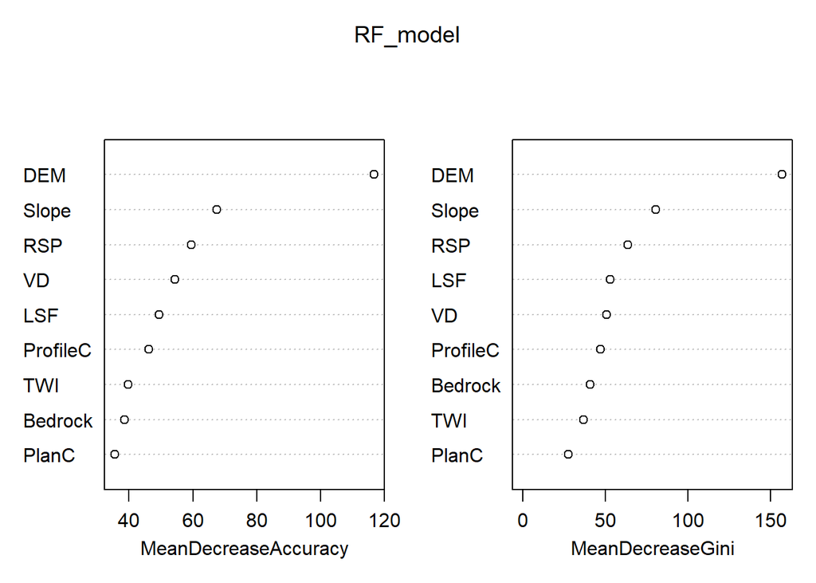

```r
sampleNum_dict[mn]<-nrow(sampData)

sampData$Bedrock<- droplevels(as.factor(sampData$Bedrock))
sampData$soilID<- droplevels(as.factor(sampData$soilID))

RF_model<-randomForest(soilID ~.,data = sampData,
                       importance = TRUE, proximity = FALSE,
                       ntree=1000,type="classification")

varImpPlot(RF_model)
```

```r
print(RF_model)
```

```
##
## Call:
##  randomForest(formula = soilID ~ ., data = sampData, importance = TRUE,      proximity = FALSE, ntree = 1000, type = "classification")
##                Type of random forest: classification
##                      Number of trees: 1000
## No. of variables tried at each split: 3
##
##         OOB estimate of  error rate: 18.9%
## Confusion matrix:
##     1 20 21 23  3 30 31 501 502 503  7 class.error
## 1   0  0  0  0  2  0  0   0   0   0  0  1.00000000
## 20  0 53 10  0  0  0  0   0   0  11  9  0.36144578
## 21  0 13 18  0  0  0  0   0   0   1  0  0.43750000
## 23  0  0  0 58  0  2  1   0   0   7  0  0.14705882
## 3   0  0  0  0 28  0  0   7   0   0  0  0.20000000
## 30  0  0  0  3  0 11  1   0   0   0  0  0.26666667
## 31  0  0  0  1  0  1 25   0   0   0  0  0.07407407
## 501 0  0  0  0  6  0  0 108   0   0  5  0.09243697
## 502 0  2  0  0  0  0  0   3   7   0  2  0.50000000
## 503 0  9  1  8  0  0  0   0   0 139  2  0.12578616
## 7   0 10  0  0  0  0  0   3   0   4 85  0.16666667
```

```r
map_RF <- predict(covStack, RF_model, paste(result_tif_folder,mn,".tif",sep=""),
                  format = "GTiff", datatype = "FLT4S", overwrite = TRUE)

rm("mn","shpPoint","sampData","RF_model","map_RF")
```

SNA PCA6 ns5 45

```r
mn="All_pSNA_PCA6_NS5_pen45"

shpPoint<-readOGR(paste(point_shp_folder,mn,".shp",sep = "")) ###
sampData <- extract(covStack, shpPoint, sp = TRUE,method = "simple")

sampData<-sampData@data

sampData<-sampData[sampData$soilID %in% soil_type,]

sampData<-na.omit(sampData)

print(dim(sampData))
```

```
## [1] 959  10
```

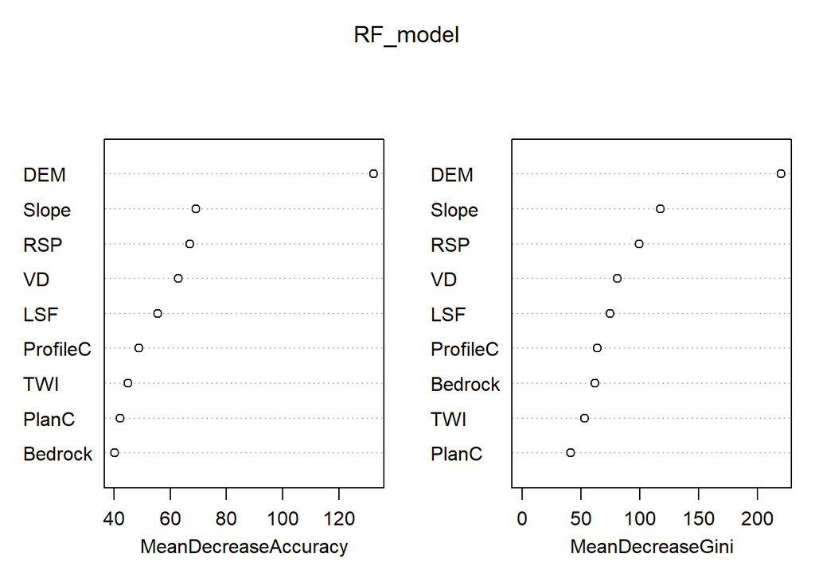

```r
sampleNum_dict[mn]<-nrow(sampData)

sampData$Bedrock<- droplevels(as.factor(sampData$Bedrock))
sampData$soilID<- droplevels(as.factor(sampData$soilID))

RF_model<-randomForest(soilID ~.,data = sampData,
                       importance = TRUE, proximity = FALSE,
                       ntree=1000,type="classification")

varImpPlot(RF_model)
```

```r
print(RF_model)
```

```
##
## Call:
##  randomForest(formula = soilID ~ ., data = sampData, importance = TRUE,      proximity = FALSE, ntree = 1000, type = "classification")
##                Type of random forest: classification
##                      Number of trees: 1000
## No. of variables tried at each split: 3
##
##         OOB estimate of  error rate: 19.5%
## Confusion matrix:
##     1 20 21 23  3 30 31 501 502 503   7 class.error
## 1   1  0  0  0  2  0  0   0   0   0   0   0.6666667
## 20  0 78 10  0  0  0  0   1   0  16  17   0.3606557
## 21  0 17 27  0  0  0  0   0   1   1   0   0.4130435
## 23  0  0  0 77  0  3  4   0   0  10   0   0.1808511
## 3   0  0  0  0 41  0  0  11   0   0   0   0.2115385
## 30  0  0  0  4  0 13  2   0   0   0   2   0.3809524
## 31  0  0  0  3  0  2 35   0   0   0   0   0.1250000
## 501 0  0  0  0 11  0  0 160   1   0   5   0.0960452
## 502 0  4  0  0  0  0  0   4  12   0   1   0.4285714
## 503 0 11  2 13  0  0  0   0   0 203   4   0.1287554
## 7   0 14  0  0  0  1  0   6   0   4 125   0.1666667
```

```r
map_RF <- predict(covStack, RF_model, paste(result_tif_folder,mn,".tif",sep=""),
                  format = "GTiff", datatype = "FLT4S", overwrite = TRUE)

rm("mn","shpPoint","sampData","RF_model","map_RF")
```

RAN PCA6 ns5 15

```r
mn="All_pRAN_PCA6_NS5_pen15"

shpPoint<-readOGR(paste(point_shp_folder,mn,".shp",sep = "")) ###
sampData <- extract(covStack, shpPoint, sp = TRUE,method = "simple")

sampData<-sampData@data

sampData<-sampData[sampData$soilID %in% soil_type,]

sampData<-na.omit(sampData)

print(dim(sampData))
```

```
## [1] 354  10
```

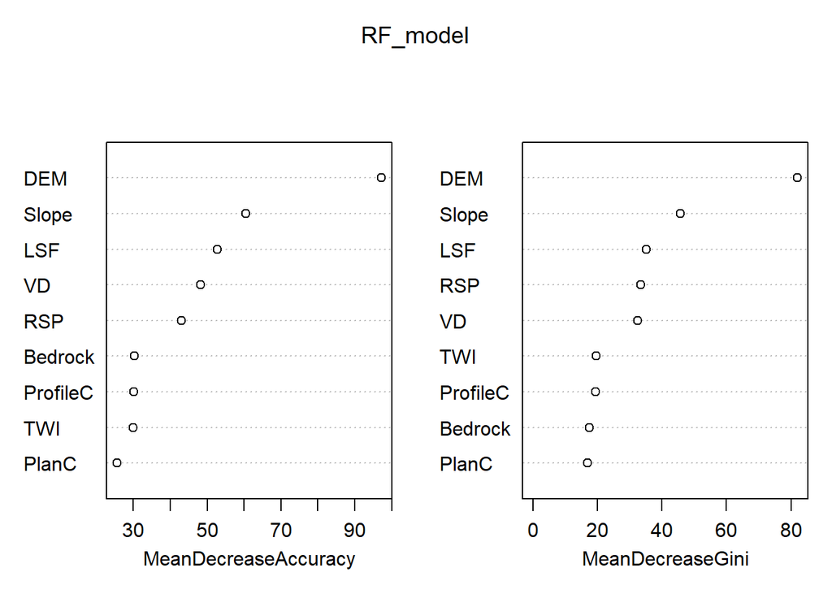

```r
sampleNum_dict[mn]<-nrow(sampData)

sampData$Bedrock<- droplevels(as.factor(sampData$Bedrock))
sampData$soilID<- droplevels(as.factor(sampData$soilID))

RF_model<-randomForest(soilID ~.,data = sampData,
                       importance = TRUE, proximity = FALSE,
                       ntree=1000,type="classification")

varImpPlot(RF_model)
```

```r
print(RF_model)
```

```
##
## Call:
##  randomForest(formula = soilID ~ ., data = sampData, importance = TRUE,      proximity = FALSE, ntree = 1000, type = "classification")
##                Type of random forest: classification
##                      Number of trees: 1000
## No. of variables tried at each split: 3
##
##         OOB estimate of  error rate: 23.73%
## Confusion matrix:
##     1 20 21 23  3 30 31 501 502 503  7 class.error
## 1   0  0  0  0  1  0  0   0   0   0  0  1.00000000
## 20  0 26  4  0  0  0  0   0   0   7  7  0.40909091
## 21  0  7 13  0  0  0  0   0   0   1  0  0.38095238
## 23  0  0  0 34  0  3  1   0   0   3  2  0.20930233
## 3   0  0  0  0 14  0  0   4   0   0  0  0.22222222
## 30  0  0  0  5  0  2  2   0   0   0  0  0.77777778
## 31  0  0  0  1  0  0 13   0   0   0  0  0.07142857
## 501 0  0  0  0  3  0  0  57   0   0  0  0.05000000
## 502 0  2  1  0  0  0  0   2   1   1  0  0.85714286
## 503 0  3  1  4  0  0  0   0   0  70  4  0.14634146
## 7   0  8  0  0  0  0  0   2   0   5 40  0.27272727
```

```r
map_RF <- predict(covStack, RF_model, paste(result_tif_folder,mn,".tif",sep=""),
                  format = "GTiff", datatype = "FLT4S", overwrite = TRUE)

rm("mn","shpPoint","sampData","RF_model","map_RF")
```

RAN PCA6 ns5 30

```r
mn="All_pRAN_PCA6_NS5_pen30"

shpPoint<-readOGR(paste(point_shp_folder,mn,".shp",sep = "")) ###
sampData <- extract(covStack, shpPoint, sp = TRUE,method = "simple")

sampData<-sampData@data

sampData<-sampData[sampData$soilID %in% soil_type,]

sampData<-na.omit(sampData)

print(dim(sampData))
```

```
## [1] 656  10
```

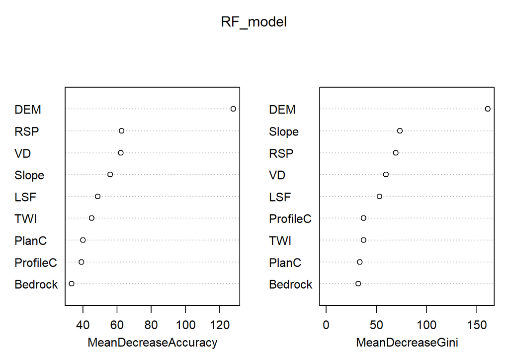

```r
sampleNum_dict[mn]<-nrow(sampData)

sampData$Bedrock<- droplevels(as.factor(sampData$Bedrock))
sampData$soilID<- droplevels(as.factor(sampData$soilID))

RF_model<-randomForest(soilID ~.,data = sampData,
                       importance = TRUE, proximity = FALSE,
                       ntree=1000,type="classification")

varImpPlot(RF_model)
```

```r
print(RF_model)
```

```
##
## Call:
##  randomForest(formula = soilID ~ ., data = sampData, importance = TRUE,      proximity = FALSE, ntree = 1000, type = "classification")
##                Type of random forest: classification
##                      Number of trees: 1000
## No. of variables tried at each split: 3
##
##         OOB estimate of  error rate: 18.6%
## Confusion matrix:
##     1 20 21 23  3 30 31 501 502 503  7 class.error
## 1   1  0  0  0  1  0  0   0   0   0  0  0.50000000
## 20  0 54  8  0  0  0  0   0   1  12  8  0.34939759
## 21  0 15 14  0  0  0  0   0   1   2  0  0.56250000
## 23  0  0  0 55  0  2  1   0   0   7  3  0.19117647
## 3   0  0  0  0 32  0  0   3   0   0  0  0.08571429
## 30  0  0  0  3  0  9  2   0   0   0  1  0.40000000
## 31  0  0  0  1  0  0 25   0   0   1  0  0.07407407
## 501 0  1  0  0  7  0  0 109   1   0  1  0.08403361
## 502 0  3  1  0  0  0  0   1   9   0  0  0.35714286
## 503 0  5  0  5  0  0  0   0   0 144  5  0.09433962
## 7   0  7  0  0  0  0  0   4   0   9 82  0.19607843
```

```r
map_RF <- predict(covStack, RF_model, paste(result_tif_folder,mn,".tif",sep=""),
                  format = "GTiff", datatype = "FLT4S", overwrite = TRUE)

rm("mn","shpPoint","sampData","RF_model","map_RF")
```

RAN PCA6 ns5 45

```r
mn="All_pRAN_PCA6_NS5_pen45"

shpPoint<-readOGR(paste(point_shp_folder,mn,".shp",sep = "")) ###
sampData <- extract(covStack, shpPoint, sp = TRUE,method = "simple")

sampData<-sampData@data

sampData<-sampData[sampData$soilID %in% soil_type,]

sampData<-na.omit(sampData)

print(dim(sampData))
```

```
## [1] 959  10
```

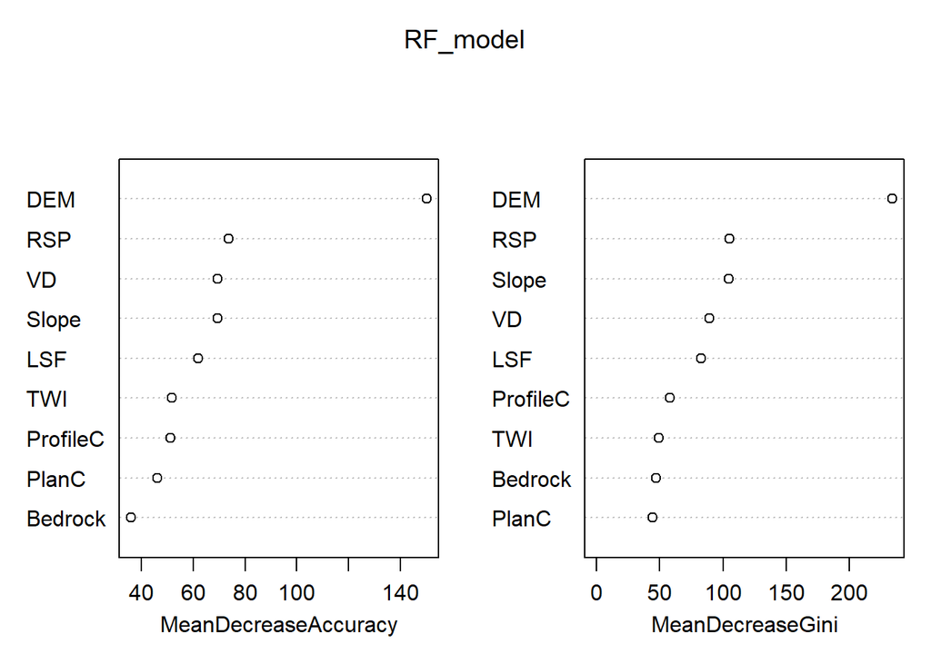

```r
sampleNum_dict[mn]<-nrow(sampData)

sampData$Bedrock<- droplevels(as.factor(sampData$Bedrock))
sampData$soilID<- droplevels(as.factor(sampData$soilID))

RF_model<-randomForest(soilID ~.,data = sampData,
                       importance = TRUE, proximity = FALSE,
                       ntree=1000,type="classification")

varImpPlot(RF_model)
```

```r
print(RF_model)
```

```
##
## Call:
##  randomForest(formula = soilID ~ ., data = sampData, importance = TRUE,      proximity = FALSE, ntree = 1000, type = "classification")
##                Type of random forest: classification
##                      Number of trees: 1000
## No. of variables tried at each split: 3
##
##         OOB estimate of  error rate: 17.21%
## Confusion matrix:
##     1 20 21 23  3 30 31 501 502 503   7 class.error
## 1   2  0  0  0  1  0  0   0   0   0   0  0.33333333
## 20  0 82  8  0  0  0  0   2   2  16  12  0.32786885
## 21  0 18 27  0  0  0  0   0   0   1   0  0.41304348
## 23  0  0  0 67  0  4  3   0   0  15   5  0.28723404
## 3   0  0  0  0 42  0  0  10   0   0   0  0.19230769
## 30  0  0  0  3  0 17  1   0   0   0   0  0.19047619
## 31  0  0  0  2  0  1 37   0   0   0   0  0.07500000
## 501 0  0  0  0  3  0  0 171   0   0   3  0.03389831
## 502 0  4  0  0  0  0  0   3  11   0   3  0.47619048
## 503 0  6  1 11  0  0  0   0   0 208   7  0.10729614
## 7   0  6  0  1  0  1  0   3   0   9 130  0.13333333
```

```r
map_RF <- predict(covStack, RF_model, paste(result_tif_folder,mn,".tif",sep=""),
                  format = "GTiff", datatype = "FLT4S", overwrite = TRUE)

rm("mn","shpPoint","sampData","RF_model","map_RF")
```

## ns7

SNA PCA6 ns7 15

```r
mn="All_pSNA_PCA6_NS7_pen15"

shpPoint<-readOGR(paste(point_shp_folder,mn,".shp",sep = "")) ###
sampData <- extract(covStack, shpPoint, sp = TRUE,method = "simple")

sampData<-sampData@data

sampData<-sampData[sampData$soilID %in% soil_type,]

sampData<-na.omit(sampData)

print(dim(sampData))
```

```
## [1] 136  10
```

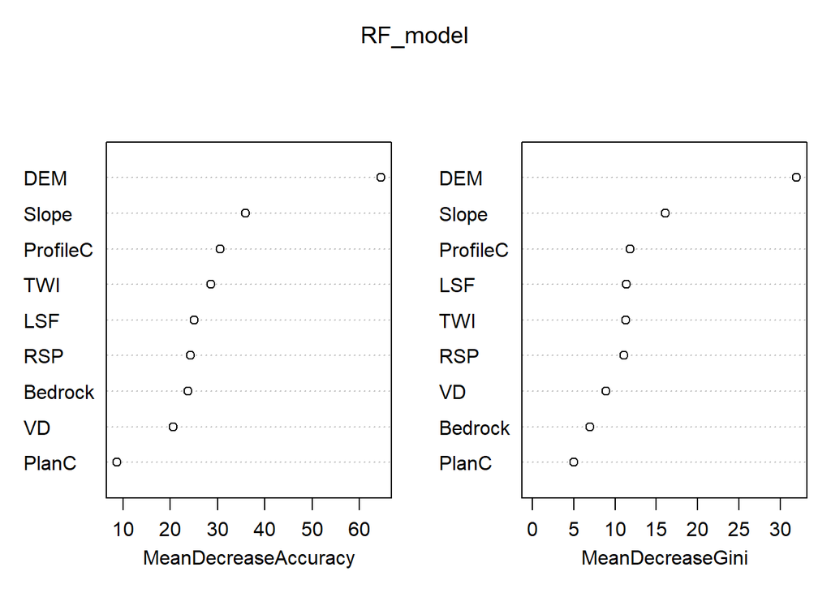

```r
sampleNum_dict[mn]<-nrow(sampData)

sampData$Bedrock<- droplevels(as.factor(sampData$Bedrock))
sampData$soilID<- droplevels(as.factor(sampData$soilID))

RF_model<-randomForest(soilID ~.,data = sampData,
                       importance = TRUE, proximity = FALSE,
                       ntree=1000,type="classification")

varImpPlot(RF_model)
```

```r
print(RF_model)
```

```
##
## Call:
##  randomForest(formula = soilID ~ ., data = sampData, importance = TRUE,      proximity = FALSE, ntree = 1000, type = "classification")
##                Type of random forest: classification
##                      Number of trees: 1000
## No. of variables tried at each split: 3
##
##         OOB estimate of  error rate: 24.26%
## Confusion matrix:
##     1 20 21 23 3 30 31 501 502 503  7 class.error
## 1   0  0  0  0 1  0  0   0   0   0  0  1.00000000
## 20  0 11  1  0 0  0  0   0   0   3  3  0.38888889
## 21  0  3  1  0 0  0  0   0   0   0  0  0.75000000
## 23  0  0  0 21 0  0  0   0   0   3  0  0.12500000
## 3   0  0  0  0 5  0  0   2   0   0  0  0.28571429
## 30  0  0  0  2 0  0  0   0   0   0  0  1.00000000
## 31  0  0  0  0 0  0  4   0   0   0  0  0.00000000
## 501 0  0  0  0 2  0  0  18   2   0  0  0.18181818
## 502 0  1  0  0 1  0  0   0   0   1  0  1.00000000
## 503 0  3  0  2 0  0  0   0   0  23  1  0.20689655
## 7   0  2  0  0 0  0  0   0   0   0 20  0.09090909
```

```r
map_RF <- predict(covStack, RF_model, paste(result_tif_folder,mn,".tif",sep=""),
                  format = "GTiff", datatype = "FLT4S", overwrite = TRUE)

rm("mn","shpPoint","sampData","RF_model","map_RF")
```

SNA PCA6 ns7 30

```r
mn="All_pSNA_PCA6_NS7_pen30"

shpPoint<-readOGR(paste(point_shp_folder,mn,".shp",sep = "")) ###
sampData <- extract(covStack, shpPoint, sp = TRUE,method = "simple")

sampData<-sampData@data

sampData<-sampData[sampData$soilID %in% soil_type,]

sampData<-na.omit(sampData)

print(dim(sampData))
```

```
## [1] 226  10
```

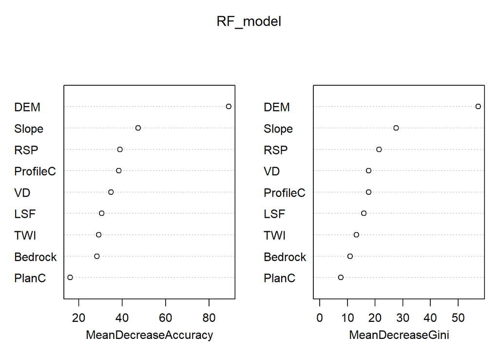

```r
sampleNum_dict[mn]<-nrow(sampData)

sampData$Bedrock<- droplevels(as.factor(sampData$Bedrock))
sampData$soilID<- droplevels(as.factor(sampData$soilID))

RF_model<-randomForest(soilID ~.,data = sampData,
                       importance = TRUE, proximity = FALSE,
                       ntree=1000,type="classification")

varImpPlot(RF_model)
```

```r
print(RF_model)
```

```
##
## Call:
##  randomForest(formula = soilID ~ ., data = sampData, importance = TRUE,      proximity = FALSE, ntree = 1000, type = "classification")
##                Type of random forest: classification
##                      Number of trees: 1000
## No. of variables tried at each split: 3
##
##         OOB estimate of  error rate: 17.7%
## Confusion matrix:
##     1 20 21 23  3 30 31 501 502 503  7 class.error
## 1   0  0  0  0  1  0  0   0   0   0  0  1.00000000
## 20  0 20  0  0  0  0  0   0   0   3  4  0.25925926
## 21  0  4  2  0  0  0  0   0   0   0  0  0.66666667
## 23  0  0  0 29  0  0  0   0   0   2  0  0.06451613
## 3   0  0  0  0 11  0  0   2   0   0  0  0.15384615
## 30  0  0  0  2  0  1  0   0   0   0  0  0.66666667
## 31  0  0  0  1  0  0  6   0   0   0  0  0.14285714
## 501 0  0  0  0  2  0  0  40   0   0  2  0.09090909
## 502 0  1  0  0  0  0  0   2   1   1  0  0.80000000
## 503 0  1  0  4  0  0  0   0   0  47  0  0.09615385
## 7   0  5  0  0  0  0  0   1   0   2 29  0.21621622
```

```r
map_RF <- predict(covStack, RF_model, paste(result_tif_folder,mn,".tif",sep=""),
                  format = "GTiff", datatype = "FLT4S", overwrite = TRUE)

rm("mn","shpPoint","sampData","RF_model","map_RF")
```

SNA PCA6 ns7 45

```r
mn="All_pSNA_PCA6_NS7_pen45"

shpPoint<-readOGR(paste(point_shp_folder,mn,".shp",sep = "")) ###
sampData <- extract(covStack, shpPoint, sp = TRUE,method = "simple")

sampData<-sampData@data

sampData<-sampData[sampData$soilID %in% soil_type,]

sampData<-na.omit(sampData)

print(dim(sampData))
```

```
## [1] 316  10
```

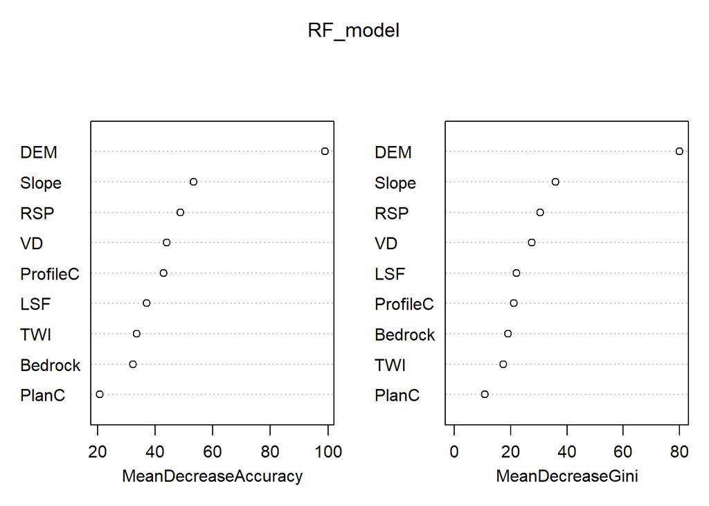

```r
sampleNum_dict[mn]<-nrow(sampData)

sampData$Bedrock<- droplevels(as.factor(sampData$Bedrock))
sampData$soilID<- droplevels(as.factor(sampData$soilID))

RF_model<-randomForest(soilID ~.,data = sampData,
                       importance = TRUE, proximity = FALSE,
                       ntree=1000,type="classification")

varImpPlot(RF_model)
```

```r
print(RF_model)
```

```
##
## Call:
##  randomForest(formula = soilID ~ ., data = sampData, importance = TRUE,      proximity = FALSE, ntree = 1000, type = "classification")
##                Type of random forest: classification
##                      Number of trees: 1000
## No. of variables tried at each split: 3
##
##         OOB estimate of  error rate: 17.41%
## Confusion matrix:
##     1 20 21 23  3 30 31 501 502 503  7 class.error
## 1   0  0  0  0  1  0  0   0   0   0  0  1.00000000
## 20  0 26  1  0  0  0  0   0   0   3  5  0.25714286
## 21  0  5  3  0  0  0  0   0   0   0  0  0.62500000
## 23  0  0  0 33  0  1  1   0   0   3  0  0.13157895
## 3   0  0  0  0 16  0  0   3   0   0  0  0.15789474
## 30  0  0  0  2  0  1  1   0   0   0  0  0.75000000
## 31  0  0  0  2  0  0  8   0   0   0  0  0.20000000
## 501 0  1  0  0  2  0  0  62   0   0  1  0.06060606
## 502 0  1  0  0  0  0  0   4   1   0  1  0.85714286
## 503 0  1  0  5  0  0  0   0   0  68  1  0.09333333
## 7   0  5  0  0  0  1  0   1   0   3 43  0.18867925
```

```r
map_RF <- predict(covStack, RF_model, paste(result_tif_folder,mn,".tif",sep=""),
                  format = "GTiff", datatype = "FLT4S", overwrite = TRUE)

rm("mn","shpPoint","sampData","RF_model","map_RF")
```

RAN PCA6 ns7 15

```r
mn="All_pRAN_PCA6_NS7_pen15"

shpPoint<-readOGR(paste(point_shp_folder,mn,".shp",sep = "")) ###
sampData <- extract(covStack, shpPoint, sp = TRUE,method = "simple")

sampData<-sampData@data

sampData<-sampData[sampData$soilID %in% soil_type,]

sampData<-na.omit(sampData)

print(dim(sampData))
```

```
## [1] 136  10
```

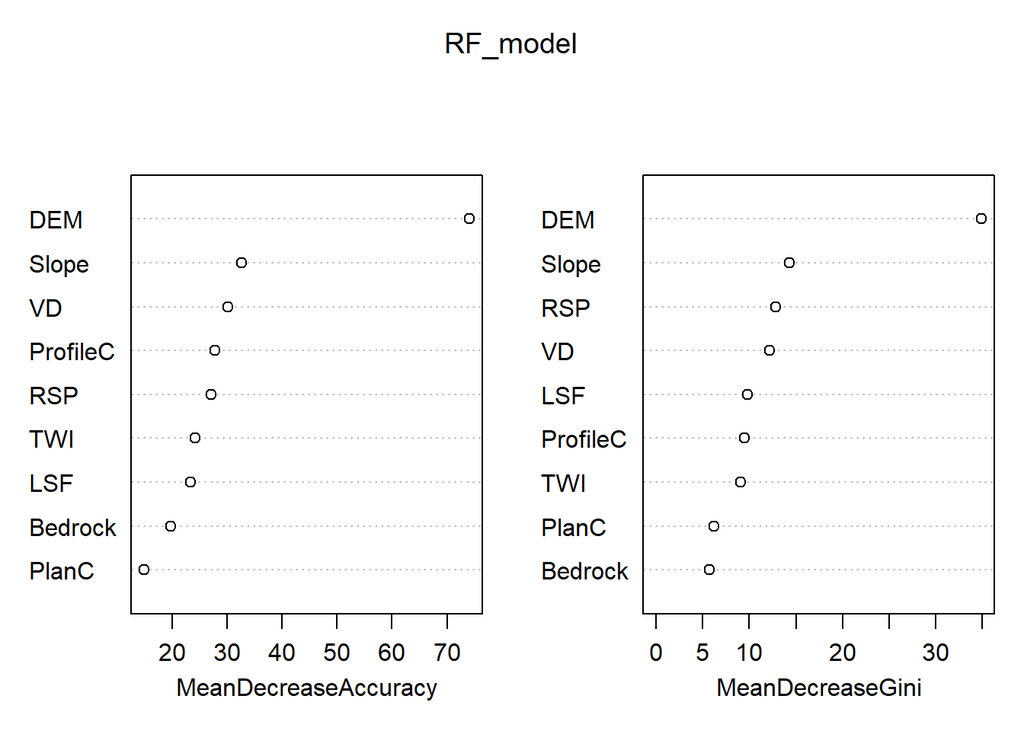

```r
sampleNum_dict[mn]<-nrow(sampData)

sampData$Bedrock<- droplevels(as.factor(sampData$Bedrock))
sampData$soilID<- droplevels(as.factor(sampData$soilID))

RF_model<-randomForest(soilID ~.,data = sampData,
                       importance = TRUE, proximity = FALSE,
                       ntree=1000,type="classification")

varImpPlot(RF_model)
```

```r
print(RF_model)
```

```
##
## Call:
##  randomForest(formula = soilID ~ ., data = sampData, importance = TRUE,      proximity = FALSE, ntree = 1000, type = "classification")
##                Type of random forest: classification
##                      Number of trees: 1000
## No. of variables tried at each split: 3
##
##         OOB estimate of  error rate: 22.06%
## Confusion matrix:
##     1 20 21 23 3 30 31 501 502 503  7 class.error
## 1   0  0  0  0 1  0  0   0   0   0  0   1.0000000
## 20  0 12  1  0 0  0  0   0   0   4  1   0.3333333
## 21  0  3  0  0 0  0  0   0   1   0  0   1.0000000
## 23  0  0  0 21 0  2  0   0   0   1  0   0.1250000
## 3   0  0  0  0 6  0  0   1   0   0  0   0.1428571
## 30  0  0  0  1 0  0  1   0   0   0  0   1.0000000
## 31  0  0  0  0 0  0  4   0   0   0  0   0.0000000
## 501 0  0  0  0 2  0  0  19   0   0  1   0.1363636
## 502 0  1  1  0 0  0  0   1   0   0  0   1.0000000
## 503 0  2  0  1 0  0  0   0   0  25  1   0.1379310
## 7   0  0  0  0 0  0  0   0   0   3 19   0.1363636
```

```r
map_RF <- predict(covStack, RF_model, paste(result_tif_folder,mn,".tif",sep=""),
                  format = "GTiff", datatype = "FLT4S", overwrite = TRUE)

rm("mn","shpPoint","sampData","RF_model","map_RF")
```

RAN PCA6 ns7 30

```r
mn="All_pRAN_PCA6_NS7_pen30"

shpPoint<-readOGR(paste(point_shp_folder,mn,".shp",sep = "")) ###
sampData <- extract(covStack, shpPoint, sp = TRUE,method = "simple")

sampData<-sampData@data

sampData<-sampData[sampData$soilID %in% soil_type,]

sampData<-na.omit(sampData)

print(dim(sampData))
```

```
## [1] 226  10
```

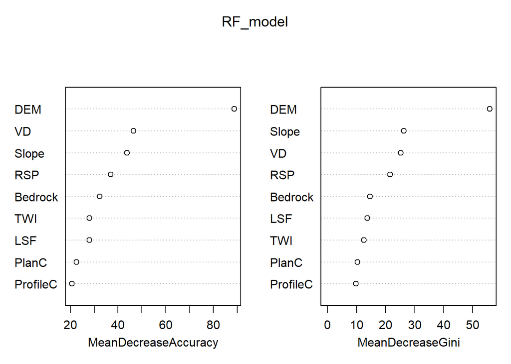

```r
sampleNum_dict[mn]<-nrow(sampData)

sampData$Bedrock<- droplevels(as.factor(sampData$Bedrock))
sampData$soilID<- droplevels(as.factor(sampData$soilID))

RF_model<-randomForest(soilID ~.,data = sampData,
                       importance = TRUE, proximity = FALSE,
                       ntree=1000,type="classification")

varImpPlot(RF_model)
```

```r
print(RF_model)
```

```
##
## Call:
##  randomForest(formula = soilID ~ ., data = sampData, importance = TRUE,      proximity = FALSE, ntree = 1000, type = "classification")
##                Type of random forest: classification
##                      Number of trees: 1000
## No. of variables tried at each split: 3
##
##         OOB estimate of  error rate: 20.35%
## Confusion matrix:
##     1 20 21 23  3 30 31 501 502 503  7 class.error
## 1   0  0  0  0  1  0  0   0   0   0  0  1.00000000
## 20  0 19  1  0  0  0  0   0   1   3  3  0.29629630
## 21  0  2  3  0  0  0  0   0   1   0  0  0.50000000
## 23  0  0  0 25  0  2  1   0   0   3  0  0.19354839
## 3   0  0  0  0 12  0  0   1   0   0  0  0.07692308
## 30  0  0  0  3  0  0  0   0   0   0  0  1.00000000
## 31  0  0  0  2  0  0  5   0   0   0  0  0.28571429
## 501 0  0  0  0  0  0  0  43   0   0  1  0.02272727
## 502 0  1  1  0  0  0  0   3   0   0  0  1.00000000
## 503 0  3  0  7  0  0  0   0   0  41  1  0.21153846
## 7   0  2  0  0  0  0  0   1   0   2 32  0.13513514
```

```r
map_RF <- predict(covStack, RF_model, paste(result_tif_folder,mn,".tif",sep=""),
                  format = "GTiff", datatype = "FLT4S", overwrite = TRUE)

rm("mn","shpPoint","sampData","RF_model","map_RF")
```

RAN PCA6 ns7 45

```r
mn="All_pRAN_PCA6_NS7_pen45"

shpPoint<-readOGR(paste(point_shp_folder,mn,".shp",sep = "")) ###
sampData <- extract(covStack, shpPoint, sp = TRUE,method = "simple")

sampData<-sampData@data

sampData<-sampData[sampData$soilID %in% soil_type,]

sampData<-na.omit(sampData)

print(dim(sampData))
```

```
## [1] 316  10
```

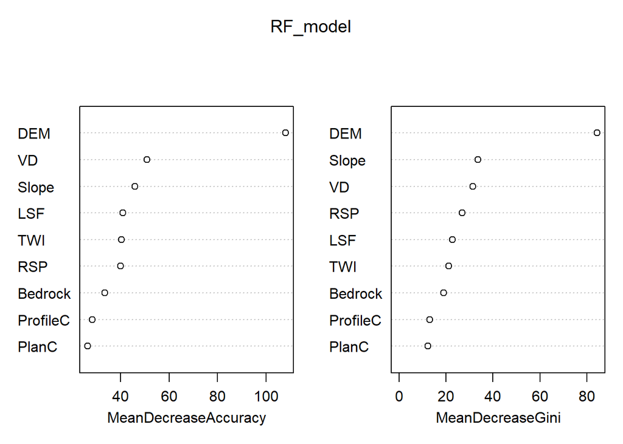

```r
sampleNum_dict[mn]<-nrow(sampData)

sampData$Bedrock<- droplevels(as.factor(sampData$Bedrock))
sampData$soilID<- droplevels(as.factor(sampData$soilID))

RF_model<-randomForest(soilID ~.,data = sampData,
                       importance = TRUE, proximity = FALSE,
                       ntree=1000,type="classification")

varImpPlot(RF_model)
```

```r
print(RF_model)
```

```
##
## Call:
##  randomForest(formula = soilID ~ ., data = sampData, importance = TRUE,      proximity = FALSE, ntree = 1000, type = "classification")
##                Type of random forest: classification
##                      Number of trees: 1000
## No. of variables tried at each split: 3
##
##         OOB estimate of  error rate: 13.92%
## Confusion matrix:
##     1 20 21 23  3 30 31 501 502 503  7 class.error
## 1   0  0  0  0  1  0  0   0   0   0  0  1.00000000
## 20  0 26  0  0  0  0  0   0   0   4  5  0.25714286
## 21  0  1  6  0  0  0  0   0   1   0  0  0.25000000
## 23  0  0  0 33  0  2  1   0   0   2  0  0.13157895
## 3   0  0  0  0 16  0  0   3   0   0  0  0.15789474
## 30  0  0  0  1  0  2  1   0   0   0  0  0.50000000
## 31  0  0  0  1  0  0  9   0   0   0  0  0.10000000
## 501 0  0  0  0  2  0  0  63   0   0  1  0.04545455
## 502 0  1  0  0  0  0  0   3   2   0  1  0.71428571
## 503 0  3  0  3  0  0  0   0   0  68  1  0.09333333
## 7   0  1  0  0  0  0  0   1   0   4 47  0.11320755
```

```r
map_RF <- predict(covStack, RF_model, paste(result_tif_folder,mn,".tif",sep=""),
                  format = "GTiff", datatype = "FLT4S", overwrite = TRUE)

rm("mn","shpPoint","sampData","RF_model","map_RF")
```

# PCA3 -ok

## ns3

SNA PCA3 ns3 15

```r
mn="All_pSNA_PCA3_NS3_pen15"

shpPoint<-readOGR(paste(point_shp_folder,mn,".shp",sep = "")) ###
sampData <- extract(covStack, shpPoint, sp = TRUE,method = "simple")

sampData<-sampData@data

sampData<-sampData[sampData$soilID %in% soil_type,]

sampData<-na.omit(sampData)

print(dim(sampData))
```

```
## [1] 992  10
```

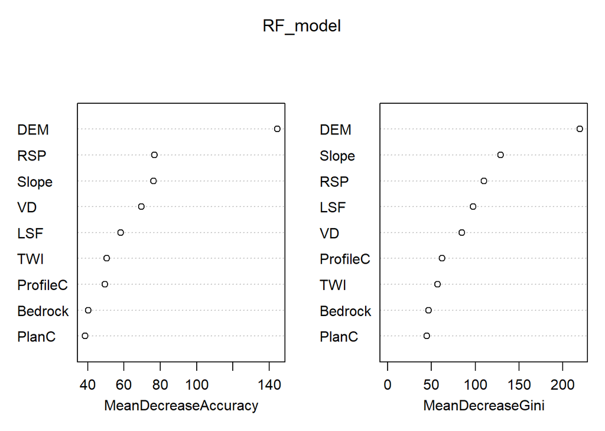

```r
sampleNum_dict[mn]<-nrow(sampData)

sampData$Bedrock<- droplevels(as.factor(sampData$Bedrock))
sampData$soilID<- droplevels(as.factor(sampData$soilID))

RF_model<-randomForest(soilID ~.,data = sampData,
                       importance = TRUE, proximity = FALSE,
                       ntree=1000,type="classification")

varImpPlot(RF_model)
```

```r
print(RF_model)
```

```
##
## Call:
##  randomForest(formula = soilID ~ ., data = sampData, importance = TRUE,      proximity = FALSE, ntree = 1000, type = "classification")
##                Type of random forest: classification
##                      Number of trees: 1000
## No. of variables tried at each split: 3
##
##         OOB estimate of  error rate: 19.86%
## Confusion matrix:
##     1  20 21 23  3 30 31 501 502 503   7 class.error
## 1   2   0  0  0  3  0  0   0   0   0   0  0.60000000
## 20  0 111 11  0  0  0  0   1   1  17  17  0.29746835
## 21  0  22 34  0  0  0  0   0   1   2   0  0.42372881
## 23  0   0  0 81  0  3  4   0   0  10   0  0.17346939
## 3   2   0  0  0 46  0  0   4   0   0   0  0.11538462
## 30  0   1  0  6  0 20  3   0   0   0   2  0.37500000
## 31  0   0  0  3  0  0 39   0   0   0   0  0.07142857
## 501 0   1  0  0 10  0  0 140   1   0   4  0.10256410
## 502 0   5  0  0  0  0  0   0  17   0   0  0.22727273
## 503 0  16  0  8  0  1  0   0   0 197   5  0.13215859
## 7   0  15  0  0  0  4  0   6   0   8 108  0.23404255
```

```r
map_RF <- predict(covStack, RF_model, paste(result_tif_folder,mn,".tif",sep=""),
                  format = "GTiff", datatype = "FLT4S", overwrite = TRUE)

rm("mn","shpPoint","sampData","RF_model","map_RF")
```

SNA PCA3 ns3 30

```r
mn="All_pSNA_PCA3_NS3_pen30"

shpPoint<-readOGR(paste(point_shp_folder,mn,".shp",sep = "")) ###
sampData <- extract(covStack, shpPoint, sp = TRUE,method = "simple")

sampData<-sampData@data

sampData<-sampData[sampData$soilID %in% soil_type,]

sampData<-na.omit(sampData)

print(dim(sampData))
```

```
## [1] 1936   10
```

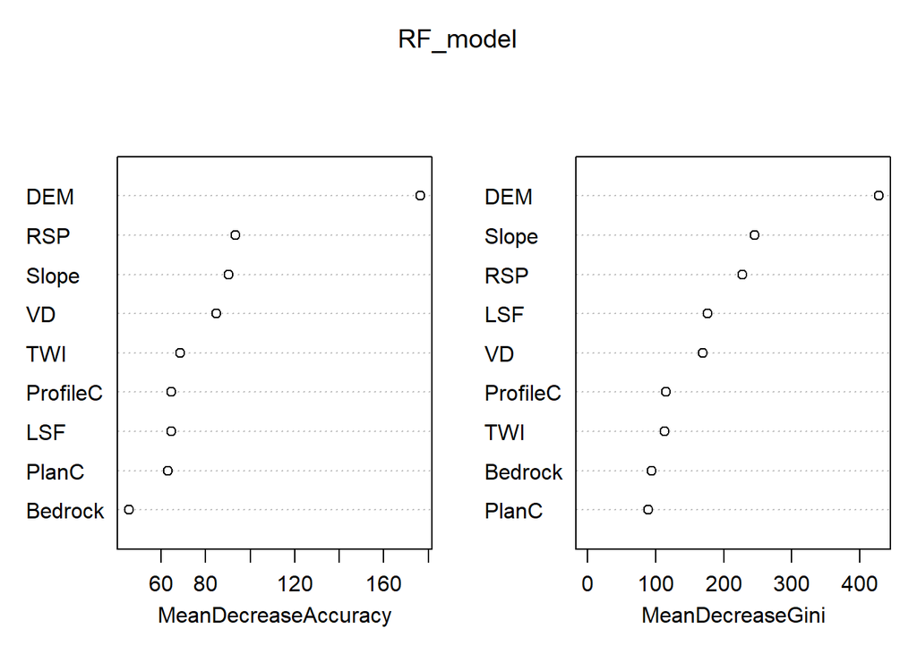

```r
sampleNum_dict[mn]<-nrow(sampData)

sampData$Bedrock<- droplevels(as.factor(sampData$Bedrock))
sampData$soilID<- droplevels(as.factor(sampData$soilID))

RF_model<-randomForest(soilID ~.,data = sampData,
                       importance = TRUE, proximity = FALSE,
                       ntree=1000,type="classification")

varImpPlot(RF_model)
```

```r
print(RF_model)
```

```
##
## Call:
##  randomForest(formula = soilID ~ ., data = sampData, importance = TRUE,      proximity = FALSE, ntree = 1000, type = "classification")
##                Type of random forest: classification
##                      Number of trees: 1000
## No. of variables tried at each split: 3
##
##         OOB estimate of  error rate: 17.98%
## Confusion matrix:
##     1  20 21  23  3 30 31 501 502 503   7 class.error
## 1   7   0  0   0  3  0  0   0   0   0   0  0.30000000
## 20  0 218 13   0  0  0  0   3   2  38  31  0.28524590
## 21  0  38 67   0  0  0  0   0   2   4   0  0.39639640
## 23  0   0  0 152  0 10  5   0   0  18   5  0.20000000
## 3   3   0  0   0 86  0  0  14   0   0   0  0.16504854
## 30  0   1  0   9  0 47  2   0   0   0   2  0.22950820
## 31  0   0  0   5  0  1 77   0   0   0   0  0.07228916
## 501 0   1  0   0  7  0  0 294   1   0   9  0.05769231
## 502 0   4  3   0  0  0  0   0  30   1   3  0.26829268
## 503 0  28  1  15  0  1  0   0   1 393   7  0.11883408
## 7   0  25  1   1  0  2  0  11   1  16 217  0.20802920
```

```r
map_RF <- predict(covStack, RF_model, paste(result_tif_folder,mn,".tif",sep=""),
                  format = "GTiff", datatype = "FLT4S", overwrite = TRUE)

rm("mn","shpPoint","sampData","RF_model","map_RF")
```

SNA PCA3 ns3 45

```r
mn="All_pSNA_PCA3_NS3_pen45"

shpPoint<-readOGR(paste(point_shp_folder,mn,".shp",sep = "")) ###
sampData <- extract(covStack, shpPoint, sp = TRUE,method = "simple")

sampData<-sampData@data

sampData<-sampData[sampData$soilID %in% soil_type,]

sampData<-na.omit(sampData)

print(dim(sampData))
```

```
## [1] 2878   10
```

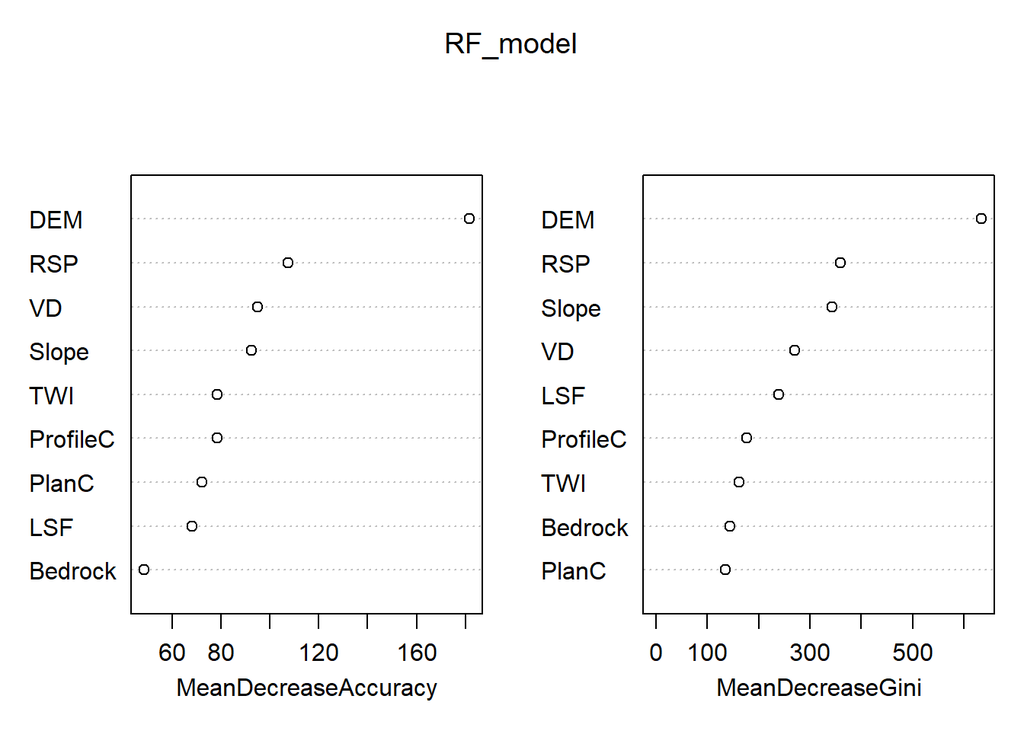

```r
sampleNum_dict[mn]<-nrow(sampData)

sampData$Bedrock<- droplevels(as.factor(sampData$Bedrock))
sampData$soilID<- droplevels(as.factor(sampData$soilID))

RF_model<-randomForest(soilID ~.,data = sampData,
                       importance = TRUE, proximity = FALSE,
                       ntree=1000,type="classification")

varImpPlot(RF_model)
```

```r
print(RF_model)
```

```
##
## Call:
##  randomForest(formula = soilID ~ ., data = sampData, importance = TRUE,      proximity = FALSE, ntree = 1000, type = "classification")
##                Type of random forest: classification
##                      Number of trees: 1000
## No. of variables tried at each split: 3
##
##         OOB estimate of  error rate: 18.52%
## Confusion matrix:
##     1  20 21  23   3 30  31 501 502 503   7 class.error
## 1   9   0  0   0   5  0   0   0   0   0   0  0.35714286
## 20  0 326 26   0   0  0   0   5   2  52  41  0.27876106
## 21  0  56 92   0   0  0   0   0   3   7   2  0.42500000
## 23  0   0  0 226   0 12   7   0   0  28   7  0.19285714
## 3   2   0  0   0 128  0   0  24   0   0   0  0.16883117
## 30  0   1  0  12   0 70   4   0   0   0   4  0.23076923
## 31  0   0  0   9   0  5 109   0   0   1   0  0.12096774
## 501 0   3  0   0  13  0   0 438   0   1  13  0.06410256
## 502 0   4  2   0   0  0   0   1  45   1   7  0.25000000
## 503 0  55  2  21   0  1   0   0   2 573  12  0.13963964
## 7   0  31  1   1   0  5   0  19   2  21 329  0.19559902
```

```r
map_RF <- predict(covStack, RF_model, paste(result_tif_folder,mn,".tif",sep=""),
                  format = "GTiff", datatype = "FLT4S", overwrite = TRUE)

rm("mn","shpPoint","sampData","RF_model","map_RF")
```

RAN PCA3 ns3 15

```r
mn="All_pRAN_PCA3_NS3_pen15"

shpPoint<-readOGR(paste(point_shp_folder,mn,".shp",sep = "")) ###
sampData <- extract(covStack, shpPoint, sp = TRUE,method = "simple")

sampData<-sampData@data

sampData<-sampData[sampData$soilID %in% soil_type,]

sampData<-na.omit(sampData)

print(dim(sampData))
```

```
## [1] 992  10
```

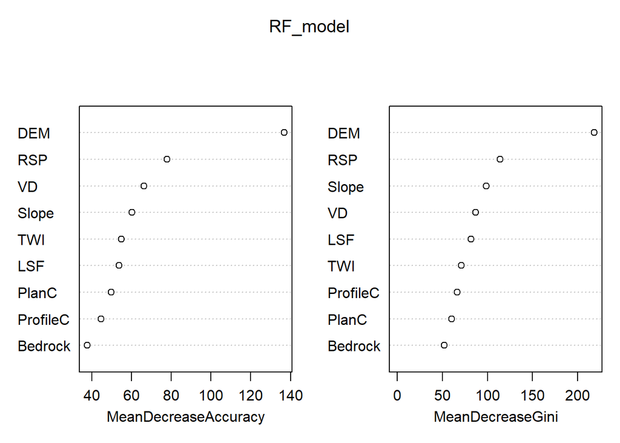

```r
sampleNum_dict[mn]<-nrow(sampData)

sampData$Bedrock<- droplevels(as.factor(sampData$Bedrock))
sampData$soilID<- droplevels(as.factor(sampData$soilID))

RF_model<-randomForest(soilID ~.,data = sampData,
                       importance = TRUE, proximity = FALSE,
                       ntree=1000,type="classification")

varImpPlot(RF_model)
```

```r
print(RF_model)
```

```
##
## Call:
##  randomForest(formula = soilID ~ ., data = sampData, importance = TRUE,      proximity = FALSE, ntree = 1000, type = "classification")
##                Type of random forest: classification
##                      Number of trees: 1000
## No. of variables tried at each split: 3
##
##         OOB estimate of  error rate: 27.02%
## Confusion matrix:
##     1  20 21 23  3 30 31 501 502 503  7 class.error
## 1   4   0  0  0  1  0  0   0   0   0  0   0.2000000
## 20  0 104 16  1  0  0  0   1   0  21 15   0.3417722
## 21  0  25 26  0  0  0  0   1   1   6  0   0.5593220
## 23  0   0  0 68  0  7  6   0   0  13  4   0.3061224
## 3   0   0  0  0 37  0  0  15   0   0  0   0.2884615
## 30  0   0  0  6  0 21  3   0   0   0  2   0.3437500
## 31  0   0  0 11  0  2 28   0   0   1  0   0.3333333
## 501 0   2  0  0 10  0  0 137   0   0  7   0.1217949
## 502 0   3  1  0  0  0  0   1  15   1  1   0.3181818
## 503 0  21  4 10  0  0  0   0   0 185  7   0.1850220
## 7   0  16  0  4  0  1  0   9   0  12 99   0.2978723
```

```r
map_RF <- predict(covStack, RF_model, paste(result_tif_folder,mn,".tif",sep=""),
                  format = "GTiff", datatype = "FLT4S", overwrite = TRUE)

rm("mn","shpPoint","sampData","RF_model","map_RF")
```

RAN PCA3 ns3 30

```r
mn="All_pRAN_PCA3_NS3_pen30"

shpPoint<-readOGR(paste(point_shp_folder,mn,".shp",sep = "")) ###
sampData <- extract(covStack, shpPoint, sp = TRUE,method = "simple")

sampData<-sampData@data

sampData<-sampData[sampData$soilID %in% soil_type,]

sampData<-na.omit(sampData)

print(dim(sampData))
```

```
## [1] 1936   10
```

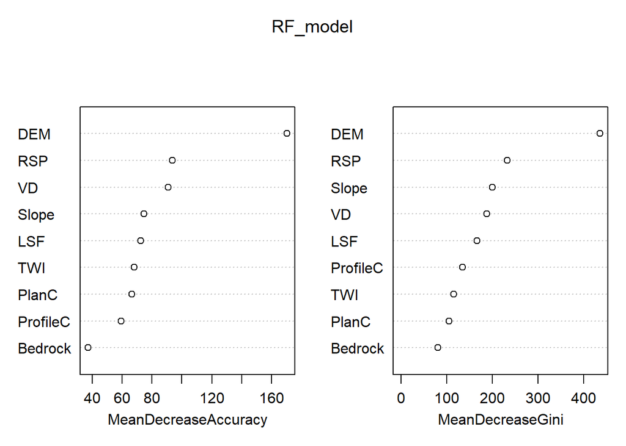

```r
sampleNum_dict[mn]<-nrow(sampData)

sampData$Bedrock<- droplevels(as.factor(sampData$Bedrock))
sampData$soilID<- droplevels(as.factor(sampData$soilID))

RF_model<-randomForest(soilID ~.,data = sampData,
                       importance = TRUE, proximity = FALSE,
                       ntree=1000,type="classification")

varImpPlot(RF_model)
```

```r
print(RF_model)
```

```
##
## Call:
##  randomForest(formula = soilID ~ ., data = sampData, importance = TRUE,      proximity = FALSE, ntree = 1000, type = "classification")
##                Type of random forest: classification
##                      Number of trees: 1000
## No. of variables tried at each split: 3
##
##         OOB estimate of  error rate: 22.62%
## Confusion matrix:
##     1  20 21  23  3 30 31 501 502 503   7 class.error
## 1   9   0  0   0  1  0  0   0   0   0   0  0.10000000
## 20  0 210 20   1  0  0  0   1   2  48  23  0.31147541
## 21  0  46 55   0  0  0  0   1   0   9   0  0.50450450
## 23  0   0  0 142  0 12  7   0   0  19  10  0.25263158
## 3   1   0  0   0 80  0  0  22   0   0   0  0.22330097
## 30  0   0  0   8  0 45  2   0   0   0   6  0.26229508
## 31  0   0  0  13  0  6 64   0   0   0   0  0.22891566
## 501 0   1  0   0 17  0  0 286   0   0   8  0.08333333
## 502 0   4  1   0  0  0  0   3  28   1   4  0.31707317
## 503 0  41  5  23  0  1  0   0   0 364  12  0.18385650
## 7   0  24  0   2  0  2  0  17   0  14 215  0.21532847
```

```r
map_RF <- predict(covStack, RF_model, paste(result_tif_folder,mn,".tif",sep=""),
                  format = "GTiff", datatype = "FLT4S", overwrite = TRUE)

rm("mn","shpPoint","sampData","RF_model","map_RF")
```

RAN PCA3 ns3 45

```r
mn="All_pRAN_PCA3_NS3_pen45"

shpPoint<-readOGR(paste(point_shp_folder,mn,".shp",sep = "")) ###
sampData <- extract(covStack, shpPoint, sp = TRUE,method = "simple")

sampData<-sampData@data

sampData<-sampData[sampData$soilID %in% soil_type,]

sampData<-na.omit(sampData)

print(dim(sampData))
```

```
## [1] 2878   10
```

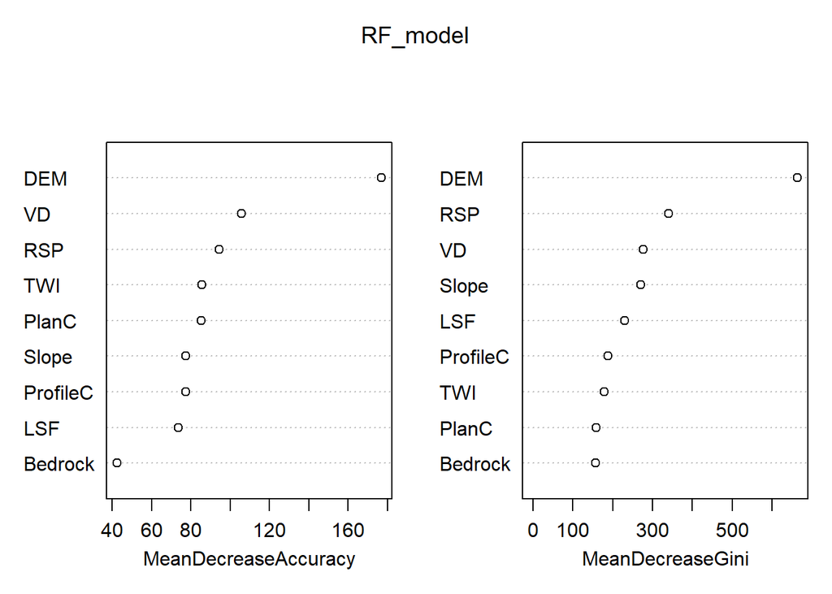

```r
sampleNum_dict[mn]<-nrow(sampData)

sampData$Bedrock<- droplevels(as.factor(sampData$Bedrock))
sampData$soilID<- droplevels(as.factor(sampData$soilID))

RF_model<-randomForest(soilID ~.,data = sampData,
                       importance = TRUE, proximity = FALSE,
                       ntree=1000,type="classification")

varImpPlot(RF_model)
```

```r
print(RF_model)
```

```
##
## Call:
##  randomForest(formula = soilID ~ ., data = sampData, importance = TRUE,      proximity = FALSE, ntree = 1000, type = "classification")
##                Type of random forest: classification
##                      Number of trees: 1000
## No. of variables tried at each split: 3
##
##         OOB estimate of  error rate: 19.53%
## Confusion matrix:
##      1  20 21  23   3 30  31 501 502 503   7 class.error
## 1   12   0  0   0   2  0   0   0   0   0   0  0.14285714
## 20   0 332 26   0   0  1   0   2   3  58  30  0.26548673
## 21   0  61 85   0   0  0   0   1   3   9   1  0.46875000
## 23   0   0  0 217   0 14   7   0   0  32  10  0.22500000
## 3    2   0  0   0 116  0   0  36   0   0   0  0.24675325
## 30   0   0  0  17   0 63   5   0   0   2   4  0.30769231
## 31   0   0  0   7   0  5 110   0   0   2   0  0.11290323
## 501  0   5  1   0  21  0   0 432   0   0   9  0.07692308
## 502  0   5  2   0   0  0   0   1  46   0   6  0.23333333
## 503  0  44  4  31   0  1   1   0   1 568  16  0.14714715
## 7    0  24  1   3   0  3   0  18   3  22 335  0.18092910
```

```r
map_RF <- predict(covStack, RF_model, paste(result_tif_folder,mn,".tif",sep=""),
                  format = "GTiff", datatype = "FLT4S", overwrite = TRUE)

rm("mn","shpPoint","sampData","RF_model","map_RF")
```

## ns5

SNA PCA3 ns5 15

```r
mn="All_pSNA_PCA3_NS5_pen15"

shpPoint<-readOGR(paste(point_shp_folder,mn,".shp",sep = "")) ###
sampData <- extract(covStack, shpPoint, sp = TRUE,method = "simple")

sampData<-sampData@data

sampData<-sampData[sampData$soilID %in% soil_type,]

sampData<-na.omit(sampData)

print(dim(sampData))
```

```
## [1] 348  10
```

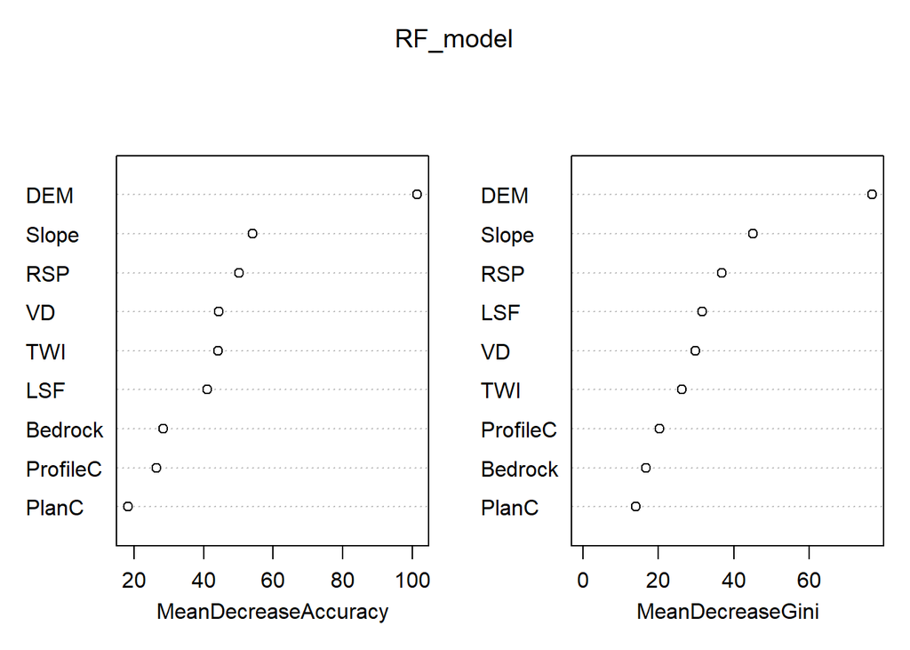

```r
sampleNum_dict[mn]<-nrow(sampData)

sampData$Bedrock<- droplevels(as.factor(sampData$Bedrock))
sampData$soilID<- droplevels(as.factor(sampData$soilID))

RF_model<-randomForest(soilID ~.,data = sampData,
                       importance = TRUE, proximity = FALSE,
                       ntree=1000,type="classification")

varImpPlot(RF_model)
```

```r
print(RF_model)
```

```
##
## Call:
##  randomForest(formula = soilID ~ ., data = sampData, importance = TRUE,      proximity = FALSE, ntree = 1000, type = "classification")
##                Type of random forest: classification
##                      Number of trees: 1000
## No. of variables tried at each split: 3
##
##         OOB estimate of  error rate: 22.13%
## Confusion matrix:
##     1 20 21 23  3 30 31 501 502 503  7 class.error
## 1   0  0  0  0  2  0  0   0   0   0  0  1.00000000
## 20  0 26  2  0  0  0  0   1   0   7  9  0.42222222
## 21  0  5 14  0  0  0  0   1   0   1  0  0.33333333
## 23  0  0  0 36  0  2  0   0   0   4  1  0.16279070
## 3   0  0  0  0 17  0  0   1   0   0  0  0.05555556
## 30  0  0  0  2  0  4  3   0   0   0  0  0.55555556
## 31  0  0  0  1  0  0 12   0   0   0  0  0.07692308
## 501 0  1  0  0  4  0  0  55   0   0  1  0.09836066
## 502 0  3  0  0  0  0  0   0   4   0  0  0.42857143
## 503 0  5  0  3  0  0  0   0   0  65  4  0.15584416
## 7   0  7  0  0  0  1  0   2   0   4 38  0.26923077
```

```r
map_RF <- predict(covStack, RF_model, paste(result_tif_folder,mn,".tif",sep=""),
                  format = "GTiff", datatype = "FLT4S", overwrite = TRUE)

rm("mn","shpPoint","sampData","RF_model","map_RF")
```

SNA PCA3 ns5 30

```r
mn="All_pSNA_PCA3_NS5_pen30"

shpPoint<-readOGR(paste(point_shp_folder,mn,".shp",sep = "")) ###
sampData <- extract(covStack, shpPoint, sp = TRUE,method = "simple")

sampData<-sampData@data

sampData<-sampData[sampData$soilID %in% soil_type,]

sampData<-na.omit(sampData)

print(dim(sampData))
```

```
## [1] 649  10
```

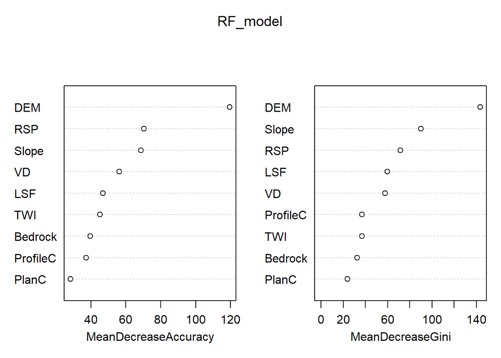

```r
sampleNum_dict[mn]<-nrow(sampData)

sampData$Bedrock<- droplevels(as.factor(sampData$Bedrock))
sampData$soilID<- droplevels(as.factor(sampData$soilID))

RF_model<-randomForest(soilID ~.,data = sampData,
                       importance = TRUE, proximity = FALSE,
                       ntree=1000,type="classification")

varImpPlot(RF_model)
```

```r
print(RF_model)
```

```
##
## Call:
##  randomForest(formula = soilID ~ ., data = sampData, importance = TRUE,      proximity = FALSE, ntree = 1000, type = "classification")
##                Type of random forest: classification
##                      Number of trees: 1000
## No. of variables tried at each split: 3
##
##         OOB estimate of  error rate: 18.49%
## Confusion matrix:
##     1 20 21 23  3 30 31 501 502 503  7 class.error
## 1   1  0  0  0  2  0  0   0   0   0  0  0.66666667
## 20  0 54  5  0  0  0  0   3   0  12 12  0.37209302
## 21  0 11 19  0  0  0  0   1   1   1  0  0.42424242
## 23  0  0  0 59  0  3  0   0   0   5  1  0.13235294
## 3   1  0  0  0 31  0  0   4   0   0  0  0.13888889
## 30  0  0  0  2  0 10  3   0   0   0  0  0.33333333
## 31  0  0  0  1  0  1 24   0   0   0  0  0.07692308
## 501 0  1  0  0  5  0  0 113   0   0  3  0.07377049
## 502 0  1  0  0  0  0  0   0  10   1  2  0.28571429
## 503 0 10  0  1  0  0  0   0   0 132  6  0.11409396
## 7   0 12  0  0  0  0  0   3   0   6 76  0.21649485
```

```r
map_RF <- predict(covStack, RF_model, paste(result_tif_folder,mn,".tif",sep=""),
                  format = "GTiff", datatype = "FLT4S", overwrite = TRUE)

rm("mn","shpPoint","sampData","RF_model","map_RF")
```

SNA PCA3 ns5 45

```r
mn="All_pSNA_PCA3_NS5_pen45"

shpPoint<-readOGR(paste(point_shp_folder,mn,".shp",sep = "")) ###
sampData <- extract(covStack, shpPoint, sp = TRUE,method = "simple")

sampData<-sampData@data

sampData<-sampData[sampData$soilID %in% soil_type,]

sampData<-na.omit(sampData)

print(dim(sampData))
```

```
## [1] 935  10
```

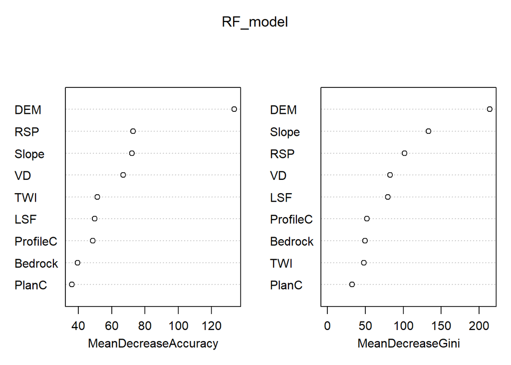

```r
sampleNum_dict[mn]<-nrow(sampData)

sampData$Bedrock<- droplevels(as.factor(sampData$Bedrock))
sampData$soilID<- droplevels(as.factor(sampData$soilID))

RF_model<-randomForest(soilID ~.,data = sampData,
                       importance = TRUE, proximity = FALSE,
                       ntree=1000,type="classification")

varImpPlot(RF_model)
```

```r
print(RF_model)
```

```
##
## Call:
##  randomForest(formula = soilID ~ ., data = sampData, importance = TRUE,      proximity = FALSE, ntree = 1000, type = "classification")
##                Type of random forest: classification
##                      Number of trees: 1000
## No. of variables tried at each split: 3
##
##         OOB estimate of  error rate: 17.01%
## Confusion matrix:
##     1 20 21 23  3 30 31 501 502 503   7 class.error
## 1   2  0  0  0  2  0  0   0   0   0   0  0.50000000
## 20  0 75 10  0  0  0  0   2   1  14  18  0.37500000
## 21  0 15 28  0  0  0  0   1   1   1   0  0.39130435
## 23  0  0  0 77  0  5  1   0   0   9   1  0.17204301
## 3   0  0  0  0 48  0  0   6   0   0   0  0.11111111
## 30  0  0  0  3  0 16  2   0   0   0   0  0.23809524
## 31  0  0  0  2  0  0 36   0   0   0   0  0.05263158
## 501 0  1  0  0  4  0  0 174   0   0   4  0.04918033
## 502 0  3  0  0  0  0  0   0  14   0   2  0.26315789
## 503 0 11  0  7  0  0  0   0   0 195   5  0.10550459
## 7   0 14  0  1  0  1  0   4   0   8 111  0.20143885
```

```r
map_RF <- predict(covStack, RF_model, paste(result_tif_folder,mn,".tif",sep=""),
                  format = "GTiff", datatype = "FLT4S", overwrite = TRUE)

rm("mn","shpPoint","sampData","RF_model","map_RF")
```

RAN PCA3 ns5 15

```r
mn="All_pRAN_PCA3_NS5_pen15"

shpPoint<-readOGR(paste(point_shp_folder,mn,".shp",sep = "")) ###
sampData <- extract(covStack, shpPoint, sp = TRUE,method = "simple")

sampData<-sampData@data

sampData<-sampData[sampData$soilID %in% soil_type,]

sampData<-na.omit(sampData)

print(dim(sampData))
```

```
## [1] 348  10
```

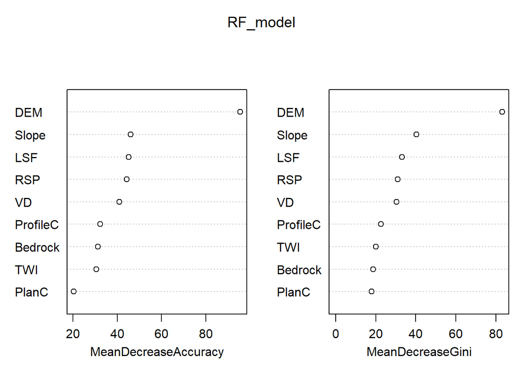

```r
sampleNum_dict[mn]<-nrow(sampData)

sampData$Bedrock<- droplevels(as.factor(sampData$Bedrock))
sampData$soilID<- droplevels(as.factor(sampData$soilID))

RF_model<-randomForest(soilID ~.,data = sampData,
                       importance = TRUE, proximity = FALSE,
                       ntree=1000,type="classification")

varImpPlot(RF_model)
```

```r
print(RF_model)
```

```
##
## Call:
##  randomForest(formula = soilID ~ ., data = sampData, importance = TRUE,      proximity = FALSE, ntree = 1000, type = "classification")
##                Type of random forest: classification
##                      Number of trees: 1000
## No. of variables tried at each split: 3
##
##         OOB estimate of  error rate: 26.72%
## Confusion matrix:
##     1 20 21 23  3 30 31 501 502 503  7 class.error
## 1   0  0  0  0  2  0  0   0   0   0  0  1.00000000
## 20  0 25  7  0  0  0  0   0   0   4  9  0.44444444
## 21  0 13  7  0  0  0  0   0   0   1  0  0.66666667
## 23  0  0  0 29  0  2  2   0   0   7  3  0.32558140
## 3   0  0  0  0 15  0  0   3   0   0  0  0.16666667
## 30  0  0  0  4  0  5  0   0   0   0  0  0.44444444
## 31  0  0  0  0  0  0 12   0   0   1  0  0.07692308
## 501 0  0  0  0  3  0  0  56   1   0  1  0.08196721
## 502 0  1  0  0  0  0  0   4   1   0  1  0.85714286
## 503 0  1  0  5  0  0  0   0   0  68  3  0.11688312
## 7   0  4  0  2  0  0  0   3   0   6 37  0.28846154
```

```r
map_RF <- predict(covStack, RF_model, paste(result_tif_folder,mn,".tif",sep=""),
                  format = "GTiff", datatype = "FLT4S", overwrite = TRUE)

rm("mn","shpPoint","sampData","RF_model","map_RF")
```

RAN PCA3 ns5 30

```r
mn="All_pRAN_PCA3_NS5_pen30"

shpPoint<-readOGR(paste(point_shp_folder,mn,".shp",sep = "")) ###
sampData <- extract(covStack, shpPoint, sp = TRUE,method = "simple")

sampData<-sampData@data

sampData<-sampData[sampData$soilID %in% soil_type,]

sampData<-na.omit(sampData)

print(dim(sampData))
```

```
## [1] 649  10
```

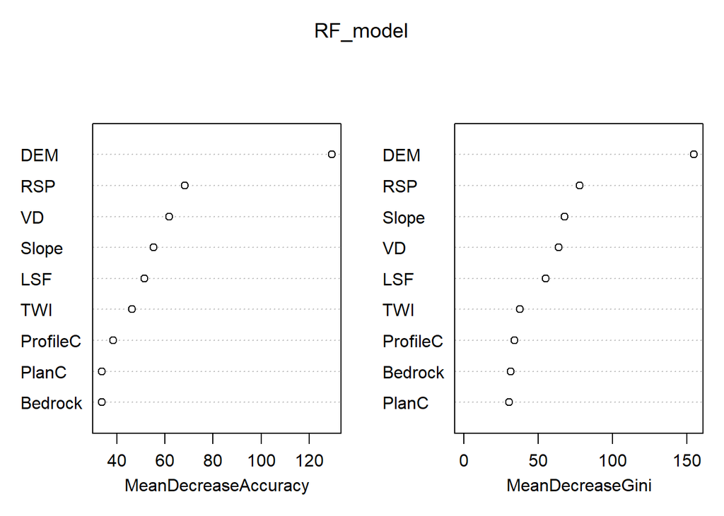

```r
sampleNum_dict[mn]<-nrow(sampData)

sampData$Bedrock<- droplevels(as.factor(sampData$Bedrock))
sampData$soilID<- droplevels(as.factor(sampData$soilID))

RF_model<-randomForest(soilID ~.,data = sampData,
                       importance = TRUE, proximity = FALSE,
                       ntree=1000,type="classification")

varImpPlot(RF_model)
```

```r
print(RF_model)
```

```
##
## Call:
##  randomForest(formula = soilID ~ ., data = sampData, importance = TRUE,      proximity = FALSE, ntree = 1000, type = "classification")
##                Type of random forest: classification
##                      Number of trees: 1000
## No. of variables tried at each split: 3
##
##         OOB estimate of  error rate: 20.34%
## Confusion matrix:
##     1 20 21 23  3 30 31 501 502 503  7 class.error
## 1   2  0  0  0  1  0  0   0   0   0  0  0.33333333
## 20  0 49  9  0  0  0  0   1   1  12 14  0.43023256
## 21  0 14 17  0  0  0  0   0   1   1  0  0.48484848
## 23  0  0  0 54  0  4  0   0   0   8  2  0.20588235
## 3   1  0  0  0 30  0  0   5   0   0  0  0.16666667
## 30  0  0  0  5  0  8  0   0   0   0  2  0.46666667
## 31  0  0  0  3  0  0 23   0   0   0  0  0.11538462
## 501 0  1  0  0  3  0  0 116   1   0  1  0.04918033
## 502 0  5  1  0  0  0  0   0   6   0  2  0.57142857
## 503 0  7  1  8  0  0  0   0   0 129  4  0.13422819
## 7   0  6  0  1  0  0  1   2   0   4 83  0.14432990
```

```r
map_RF <- predict(covStack, RF_model, paste(result_tif_folder,mn,".tif",sep=""),
                  format = "GTiff", datatype = "FLT4S", overwrite = TRUE)

rm("mn","shpPoint","sampData","RF_model","map_RF")
```

RAN PCA3 ns5 45

```r
mn="All_pRAN_PCA3_NS5_pen45"

shpPoint<-readOGR(paste(point_shp_folder,mn,".shp",sep = "")) ###
sampData <- extract(covStack, shpPoint, sp = TRUE,method = "simple")

sampData<-sampData@data

sampData<-sampData[sampData$soilID %in% soil_type,]

sampData<-na.omit(sampData)

print(dim(sampData))
```

```
## [1] 935  10
```

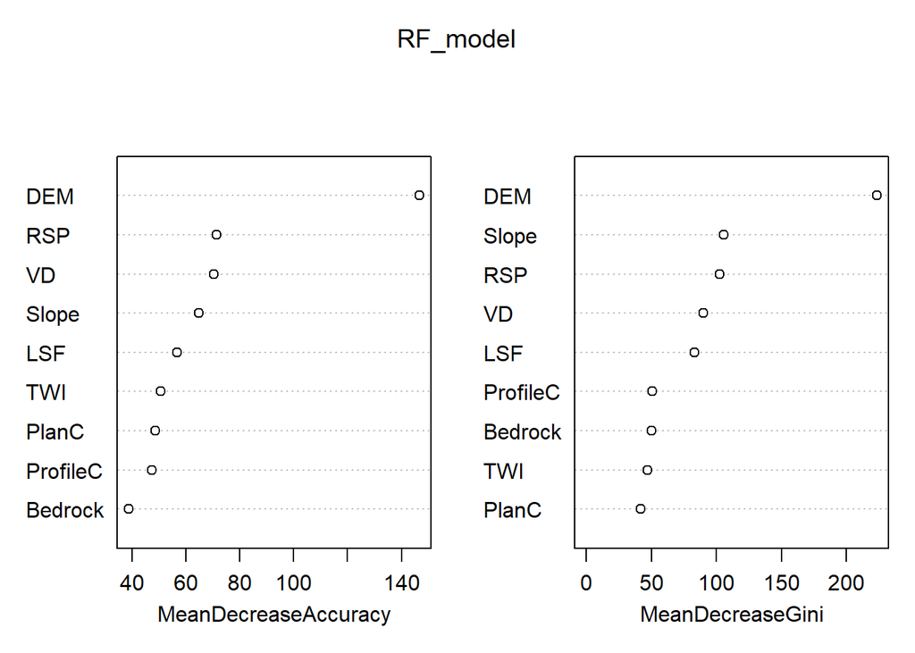

```r
sampleNum_dict[mn]<-nrow(sampData)

sampData$Bedrock<- droplevels(as.factor(sampData$Bedrock))
sampData$soilID<- droplevels(as.factor(sampData$soilID))

RF_model<-randomForest(soilID ~.,data = sampData,
                       importance = TRUE, proximity = FALSE,
                       ntree=1000,type="classification")

varImpPlot(RF_model)
```

```r
print(RF_model)
```

```
##
## Call:
##  randomForest(formula = soilID ~ ., data = sampData, importance = TRUE,      proximity = FALSE, ntree = 1000, type = "classification")
##                Type of random forest: classification
##                      Number of trees: 1000
## No. of variables tried at each split: 3
##
##         OOB estimate of  error rate: 18.29%
## Confusion matrix:
##     1 20 21 23  3 30 31 501 502 503   7 class.error
## 1   4  0  0  0  0  0  0   0   0   0   0  0.00000000
## 20  0 78 13  0  0  0  0   1   1  13  14  0.35000000
## 21  0 15 29  0  0  0  0   0   1   1   0  0.36956522
## 23  0  0  0 68  0  6  5   0   0  11   3  0.26881720
## 3   0  0  0  0 41  0  0  13   0   0   0  0.24074074
## 30  0  0  0  8  0 13  0   0   0   0   0  0.38095238
## 31  0  0  0  5  0  0 33   0   0   0   0  0.13157895
## 501 0  1  0  0  6  0  0 174   0   0   2  0.04918033
## 502 0  3  1  0  0  0  0   1  12   0   2  0.36842105
## 503 0  7  1  6  0  0  0   0   0 195   9  0.10550459
## 7   0  8  0  2  0  1  0   4   0   7 117  0.15827338
```

```r
map_RF <- predict(covStack, RF_model, paste(result_tif_folder,mn,".tif",sep=""),
                  format = "GTiff", datatype = "FLT4S", overwrite = TRUE)

rm("mn","shpPoint","sampData","RF_model","map_RF")
```

## ns7

SNA PCA3 ns7 15

```r
mn="All_pSNA_PCA3_NS7_pen15"

shpPoint<-readOGR(paste(point_shp_folder,mn,".shp",sep = "")) ###
sampData <- extract(covStack, shpPoint, sp = TRUE,method = "simple")

sampData<-sampData@data

sampData<-sampData[sampData$soilID %in% soil_type,]

sampData<-na.omit(sampData)

print(dim(sampData))
```

```
## [1] 135  10
```

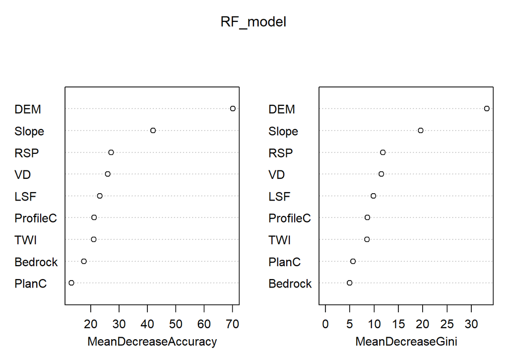

```r
sampleNum_dict[mn]<-nrow(sampData)

sampData$Bedrock<- droplevels(as.factor(sampData$Bedrock))
sampData$soilID<- droplevels(as.factor(sampData$soilID))

RF_model<-randomForest(soilID ~.,data = sampData,
                       importance = TRUE, proximity = FALSE,
                       ntree=1000,type="classification")

varImpPlot(RF_model)
```

```r
print(RF_model)
```

```
##
## Call:
##  randomForest(formula = soilID ~ ., data = sampData, importance = TRUE,      proximity = FALSE, ntree = 1000, type = "classification")
##                Type of random forest: classification
##                      Number of trees: 1000
## No. of variables tried at each split: 3
##
##         OOB estimate of  error rate: 26.67%
## Confusion matrix:
##     1 20 21 23 3 30 31 501 502 503  7 class.error
## 1   0  0  0  0 1  0  0   0   0   0  0  1.00000000
## 20  0 10  1  0 0  0  0   0   0   3  4  0.44444444
## 21  0  3  1  0 0  0  0   0   0   0  0  0.75000000
## 23  0  0  0 22 0  0  0   0   0   3  0  0.12000000
## 3   0  0  0  0 6  0  0   1   0   0  0  0.14285714
## 30  0  0  0  2 0  0  0   0   0   0  0  1.00000000
## 31  0  0  0  0 0  0  4   0   0   0  0  0.00000000
## 501 0  0  0  0 2  0  0  21   0   0  0  0.08695652
## 502 0  2  0  0 0  0  0   0   0   0  1  1.00000000
## 503 0  1  0  1 0  0  0   0   0  23  3  0.17857143
## 7   0  4  0  0 0  0  0   1   0   3 12  0.40000000
```

```r
map_RF <- predict(covStack, RF_model, paste(result_tif_folder,mn,".tif",sep=""),
                  format = "GTiff", datatype = "FLT4S", overwrite = TRUE)

rm("mn","shpPoint","sampData","RF_model","map_RF")
```

SNA PCA3 ns7 30

```r
mn="All_pSNA_PCA3_NS7_pen30"

shpPoint<-readOGR(paste(point_shp_folder,mn,".shp",sep = "")) ###
sampData <- extract(covStack, shpPoint, sp = TRUE,method = "simple")

sampData<-sampData@data

sampData<-sampData[sampData$soilID %in% soil_type,]

sampData<-na.omit(sampData)

print(dim(sampData))
```

```
## [1] 229  10
```

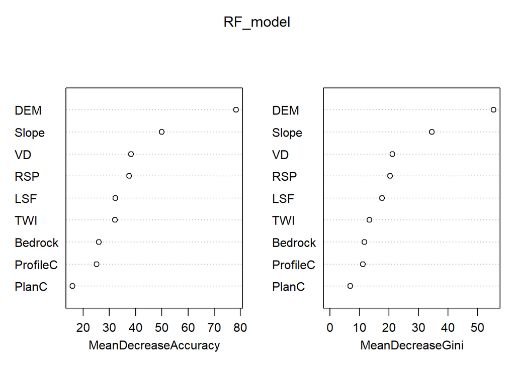

```r
sampleNum_dict[mn]<-nrow(sampData)

sampData$Bedrock<- droplevels(as.factor(sampData$Bedrock))
sampData$soilID<- droplevels(as.factor(sampData$soilID))

RF_model<-randomForest(soilID ~.,data = sampData,
                       importance = TRUE, proximity = FALSE,
                       ntree=1000,type="classification")

varImpPlot(RF_model)
```

```r
print(RF_model)
```

```
##
## Call:
##  randomForest(formula = soilID ~ ., data = sampData, importance = TRUE,      proximity = FALSE, ntree = 1000, type = "classification")
##                Type of random forest: classification
##                      Number of trees: 1000
## No. of variables tried at each split: 3
##
##         OOB estimate of  error rate: 20.09%
## Confusion matrix:
##     1 20 21 23  3 30 31 501 502 503  7 class.error
## 1   0  0  0  0  1  0  0   0   0   0  0  1.00000000
## 20  0 18  1  0  0  0  0   0   0   2  6  0.33333333
## 21  0  2  3  0  0  0  0   0   0   0  0  0.40000000
## 23  0  0  0 30  0  0  0   0   0   4  0  0.11764706
## 3   0  0  0  0 11  0  0   2   0   0  0  0.15384615
## 30  0  0  0  2  0  1  0   0   0   0  0  0.66666667
## 31  0  0  0  1  0  0  7   0   0   0  0  0.12500000
## 501 0  0  0  0  1  0  0  42   1   0  1  0.06666667
## 502 0  2  0  0  1  0  0   0   1   1  0  0.80000000
## 503 0  2  0  3  0  0  0   0   0  43  4  0.17307692
## 7   0  2  0  0  0  1  0   1   0   5 27  0.25000000
```

```r
map_RF <- predict(covStack, RF_model, paste(result_tif_folder,mn,".tif",sep=""),
                  format = "GTiff", datatype = "FLT4S", overwrite = TRUE)

rm("mn","shpPoint","sampData","RF_model","map_RF")
```

SNA PCA3 ns7 45

```r
mn="All_pSNA_PCA3_NS7_pen45"

shpPoint<-readOGR(paste(point_shp_folder,mn,".shp",sep = "")) ###
sampData <- extract(covStack, shpPoint, sp = TRUE,method = "simple")

sampData<-sampData@data

sampData<-sampData[sampData$soilID %in% soil_type,]

sampData<-na.omit(sampData)

print(dim(sampData))
```

```
## [1] 320  10
```

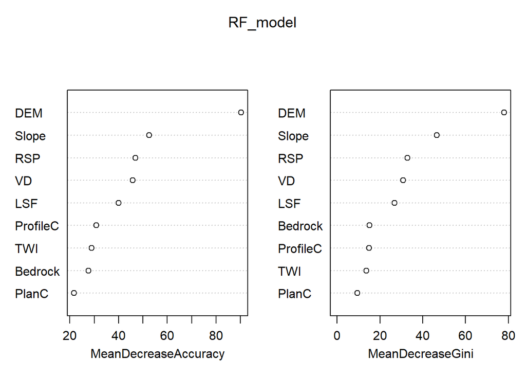

```r
sampleNum_dict[mn]<-nrow(sampData)

sampData$Bedrock<- droplevels(as.factor(sampData$Bedrock))
sampData$soilID<- droplevels(as.factor(sampData$soilID))

RF_model<-randomForest(soilID ~.,data = sampData,
                       importance = TRUE, proximity = FALSE,
                       ntree=1000,type="classification")

varImpPlot(RF_model)
```

```r
print(RF_model)
```

```
##
## Call:
##  randomForest(formula = soilID ~ ., data = sampData, importance = TRUE,      proximity = FALSE, ntree = 1000, type = "classification")
##                Type of random forest: classification
##                      Number of trees: 1000
## No. of variables tried at each split: 3
##
##         OOB estimate of  error rate: 15.31%
## Confusion matrix:
##     1 20 21 23  3 30 31 501 502 503  7 class.error
## 1   0  0  0  0  1  0  0   0   0   0  0  1.00000000
## 20  0 25  1  0  0  0  0   0   1   3  6  0.30555556
## 21  0  2  6  0  0  0  0   0   0   0  0  0.25000000
## 23  0  0  0 34  0  0  1   0   0   5  1  0.17073171
## 3   0  0  0  0 18  0  0   1   0   0  0  0.05263158
## 30  0  0  0  1  0  3  0   0   0   0  0  0.25000000
## 31  0  0  0  1  0  0 11   0   0   0  0  0.08333333
## 501 0  0  0  0  1  0  0  66   0   0  1  0.02941176
## 502 0  2  0  0  0  0  0   1   4   0  0  0.42857143
## 503 0  1  0  3  0  0  0   0   0  67  3  0.09459459
## 7   0  5  0  1  0  0  0   1   0   6 37  0.26000000
```

```r
map_RF <- predict(covStack, RF_model, paste(result_tif_folder,mn,".tif",sep=""),
                  format = "GTiff", datatype = "FLT4S", overwrite = TRUE)

rm("mn","shpPoint","sampData","RF_model","map_RF")
```

RAN PCA3 ns7 15

```r
mn="All_pRAN_PCA3_NS7_pen15"

shpPoint<-readOGR(paste(point_shp_folder,mn,".shp",sep = "")) ###
sampData <- extract(covStack, shpPoint, sp = TRUE,method = "simple")

sampData<-sampData@data

sampData<-sampData[sampData$soilID %in% soil_type,]

sampData<-na.omit(sampData)

print(dim(sampData))
```

```
## [1] 135  10
```

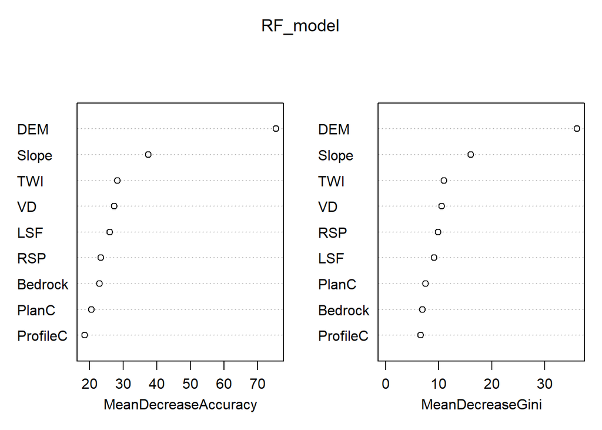

```r
sampleNum_dict[mn]<-nrow(sampData)

sampData$Bedrock<- droplevels(as.factor(sampData$Bedrock))
sampData$soilID<- droplevels(as.factor(sampData$soilID))

RF_model<-randomForest(soilID ~.,data = sampData,
                       importance = TRUE, proximity = FALSE,
                       ntree=1000,type="classification")

varImpPlot(RF_model)
```

```r
print(RF_model)
```

```
##
## Call:
##  randomForest(formula = soilID ~ ., data = sampData, importance = TRUE,      proximity = FALSE, ntree = 1000, type = "classification")
##                Type of random forest: classification
##                      Number of trees: 1000
## No. of variables tried at each split: 3
##
##         OOB estimate of  error rate: 20%
## Confusion matrix:
##     1 20 21 23 3 30 31 501 502 503  7 class.error
## 1   0  0  0  0 1  0  0   0   0   0  0  1.00000000
## 20  0 14  1  0 0  0  0   0   0   2  1  0.22222222
## 21  0  3  1  0 0  0  0   0   0   0  0  0.75000000
## 23  0  0  0 24 0  0  1   0   0   0  0  0.04000000
## 3   1  0  0  0 5  0  0   1   0   0  0  0.28571429
## 30  0  0  0  0 0  0  0   0   0   0  2  1.00000000
## 31  0  0  0  1 0  0  3   0   0   0  0  0.25000000
## 501 0  1  0  0 0  0  0  21   1   0  0  0.08695652
## 502 0  1  0  0 0  0  0   1   1   0  0  0.66666667
## 503 0  0  1  1 0  0  0   0   0  24  2  0.14285714
## 7   0  3  0  0 0  2  0   0   0   0 15  0.25000000
```

```r
map_RF <- predict(covStack, RF_model, paste(result_tif_folder,mn,".tif",sep=""),
                  format = "GTiff", datatype = "FLT4S", overwrite = TRUE)

rm("mn","shpPoint","sampData","RF_model","map_RF")
```

RAN PCA3 ns7 30

```r
mn="All_pRAN_PCA3_NS7_pen30"

shpPoint<-readOGR(paste(point_shp_folder,mn,".shp",sep = "")) ###
sampData <- extract(covStack, shpPoint, sp = TRUE,method = "simple")

sampData<-sampData@data

sampData<-sampData[sampData$soilID %in% soil_type,]

sampData<-na.omit(sampData)

print(dim(sampData))
```

```
## [1] 229  10
```

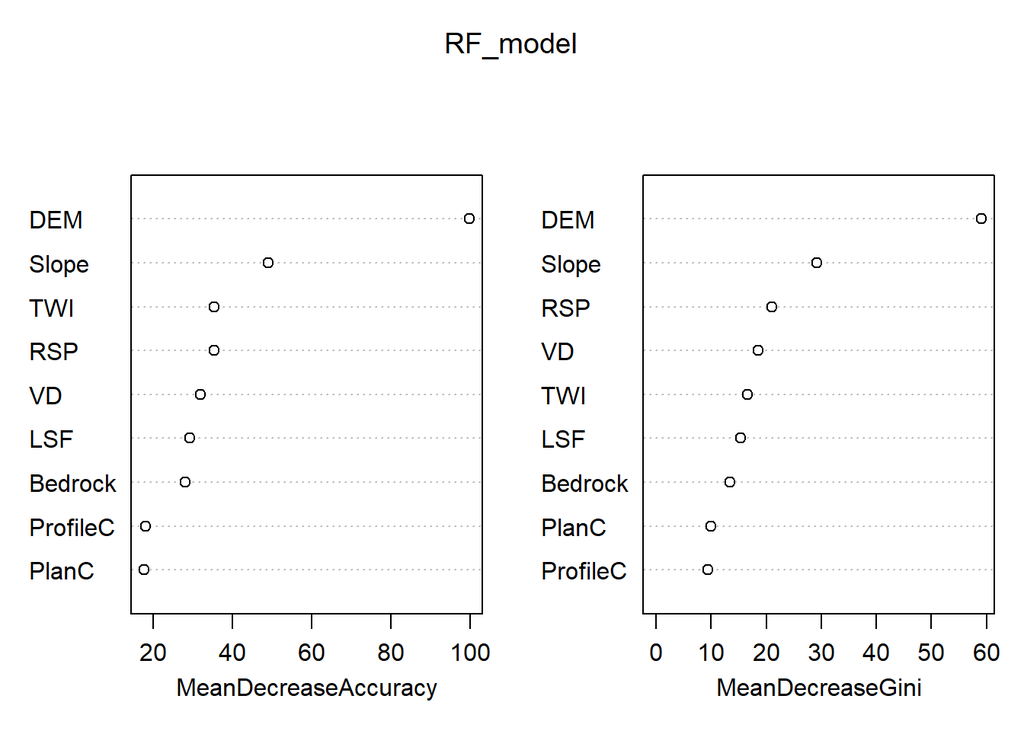

```r
sampleNum_dict[mn]<-nrow(sampData)

sampData$Bedrock<- droplevels(as.factor(sampData$Bedrock))
sampData$soilID<- droplevels(as.factor(sampData$soilID))

RF_model<-randomForest(soilID ~.,data = sampData,
                       importance = TRUE, proximity = FALSE,
                       ntree=1000,type="classification")

varImpPlot(RF_model)
```

```r
print(RF_model)
```

```
##
## Call:
##  randomForest(formula = soilID ~ ., data = sampData, importance = TRUE,      proximity = FALSE, ntree = 1000, type = "classification")
##                Type of random forest: classification
##                      Number of trees: 1000
## No. of variables tried at each split: 3
##
##         OOB estimate of  error rate: 22.27%
## Confusion matrix:
##     1 20 21 23  3 30 31 501 502 503  7 class.error
## 1   0  0  0  0  1  0  0   0   0   0  0  1.00000000
## 20  0 17  2  0  0  0  0   1   0   3  4  0.37037037
## 21  0  2  2  0  0  0  0   0   1   0  0  0.60000000
## 23  0  0  0 29  0  2  0   0   0   3  0  0.14705882
## 3   0  0  0  0 10  0  0   3   0   0  0  0.23076923
## 30  0  0  0  3  0  0  0   0   0   0  0  1.00000000
## 31  0  0  0  2  0  0  6   0   0   0  0  0.25000000
## 501 0  1  0  0  2  0  0  42   0   0  0  0.06666667
## 502 0  2  0  0  0  0  0   2   1   0  0  0.80000000
## 503 0  3  0  4  0  0  0   0   0  43  2  0.17307692
## 7   0  4  0  0  0  0  0   1   0   3 28  0.22222222
```

```r
map_RF <- predict(covStack, RF_model, paste(result_tif_folder,mn,".tif",sep=""),
                  format = "GTiff", datatype = "FLT4S", overwrite = TRUE)

rm("mn","shpPoint","sampData","RF_model","map_RF")
```

RAN PCA3 ns7 45

```r
mn="All_pRAN_PCA3_NS7_pen45"

shpPoint<-readOGR(paste(point_shp_folder,mn,".shp",sep = "")) ###
sampData <- extract(covStack, shpPoint, sp = TRUE,method = "simple")

sampData<-sampData@data

sampData<-sampData[sampData$soilID %in% soil_type,]

sampData<-na.omit(sampData)

print(dim(sampData))
```

```
## [1] 320  10
```

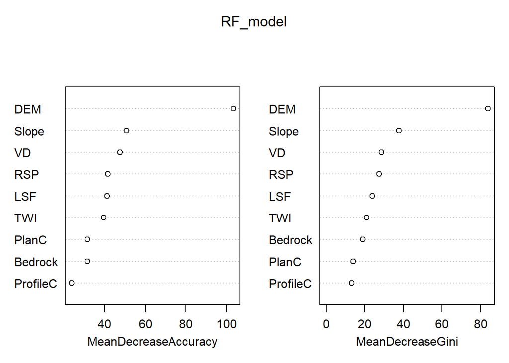

```r
sampleNum_dict[mn]<-nrow(sampData)

sampData$Bedrock<- droplevels(as.factor(sampData$Bedrock))
sampData$soilID<- droplevels(as.factor(sampData$soilID))

RF_model<-randomForest(soilID ~.,data = sampData,
                       importance = TRUE, proximity = FALSE,
                       ntree=1000,type="classification")

varImpPlot(RF_model)
```

```r
print(RF_model)
```

```
##
## Call:
##  randomForest(formula = soilID ~ ., data = sampData, importance = TRUE,      proximity = FALSE, ntree = 1000, type = "classification")
##                Type of random forest: classification
##                      Number of trees: 1000
## No. of variables tried at each split: 3
##
##         OOB estimate of  error rate: 16.25%
## Confusion matrix:
##     1 20 21 23  3 30 31 501 502 503  7 class.error
## 1   0  0  0  0  1  0  0   0   0   0  0  1.00000000
## 20  0 27  1  0  0  0  0   1   0   3  4  0.25000000
## 21  0  2  6  0  0  0  0   0   0   0  0  0.25000000
## 23  0  0  0 35  0  1  1   0   0   4  0  0.14634146
## 3   0  0  0  0 15  0  0   4   0   0  0  0.21052632
## 30  0  0  0  2  0  2  0   0   0   0  0  0.50000000
## 31  0  0  0  2  0  0 10   0   0   0  0  0.16666667
## 501 0  0  0  0  1  0  0  64   1   0  2  0.05882353
## 502 0  3  0  0  0  0  0   3   1   0  0  0.85714286
## 503 0  4  0  4  0  0  0   0   0  64  2  0.13513514
## 7   0  1  0  0  0  0  0   1   0   4 44  0.12000000
```

```r
map_RF <- predict(covStack, RF_model, paste(result_tif_folder,mn,".tif",sep=""),
                  format = "GTiff", datatype = "FLT4S", overwrite = TRUE)

rm("mn","shpPoint","sampData","RF_model","map_RF")
```

```r
#设置最终结果tif的保存路径
result_tif_folder="E:/soilPaper/modling/result_mapTif/"

result_map_name<-c("All_pSNA_PCA8_NS3_pen15","All_pSNA_PCA8_NS5_pen15","All_pSNA_PCA8_NS7_pen15",
                   "All_pRAN_PCA8_NS3_pen15","All_pRAN_PCA8_NS5_pen15","All_pRAN_PCA8_NS7_pen15",
                   "All_pSNA_PCA8_NS3_pen30","All_pSNA_PCA8_NS5_pen30","All_pSNA_PCA8_NS7_pen30",
                   "All_pRAN_PCA8_NS3_pen30","All_pRAN_PCA8_NS5_pen30","All_pRAN_PCA8_NS7_pen30",
                   "All_pSNA_PCA8_NS3_pen45","All_pSNA_PCA8_NS5_pen45","All_pSNA_PCA8_NS7_pen45",
                   "All_pRAN_PCA8_NS3_pen45","All_pRAN_PCA8_NS5_pen45","All_pRAN_PCA8_NS7_pen45",
                   "All_pSNA_PCA6_NS3_pen15","All_pSNA_PCA6_NS5_pen15","All_pSNA_PCA6_NS7_pen15",
                   "All_pRAN_PCA6_NS3_pen15","All_pRAN_PCA6_NS5_pen15","All_pRAN_PCA6_NS7_pen15",
                   "All_pSNA_PCA6_NS3_pen30","All_pSNA_PCA6_NS5_pen30","All_pSNA_PCA6_NS7_pen30",
                   "All_pRAN_PCA6_NS3_pen30","All_pRAN_PCA6_NS5_pen30","All_pRAN_PCA6_NS7_pen30",
                   "All_pSNA_PCA6_NS3_pen45","All_pSNA_PCA6_NS5_pen45","All_pSNA_PCA6_NS7_pen45",
                   "All_pRAN_PCA6_NS3_pen45","All_pRAN_PCA6_NS5_pen45","All_pRAN_PCA6_NS7_pen45",
                   "All_pSNA_PCA3_NS3_pen15","All_pSNA_PCA3_NS5_pen15","All_pSNA_PCA3_NS7_pen15",
                   "All_pRAN_PCA3_NS3_pen15","All_pRAN_PCA3_NS5_pen15","All_pRAN_PCA3_NS7_pen15",
                   "All_pSNA_PCA3_NS3_pen30","All_pSNA_PCA3_NS5_pen30","All_pSNA_PCA3_NS7_pen30",
                   "All_pRAN_PCA3_NS3_pen30","All_pRAN_PCA3_NS5_pen30","All_pRAN_PCA3_NS7_pen30",
                   "All_pSNA_PCA3_NS3_pen45","All_pSNA_PCA3_NS5_pen45","All_pSNA_PCA3_NS7_pen45",
                   "All_pRAN_PCA3_NS3_pen45","All_pRAN_PCA3_NS5_pen45","All_pRAN_PCA3_NS7_pen45")

resultCovStack<-raster(paste(result_tif_folder,result_map_name[1],".tif",sep = ""))
for (i in 2:length(result_map_name)) {
  resultCovStack <- stack(resultCovStack, raster(paste(result_tif_folder,result_map_name[i],".tif",sep = "")))
}

validationPoint<-readOGR(paste(result_tif_folder,"validationPoint.shp",sep = "")) ###
vp_data <- extract(resultCovStack, validationPoint, sp = TRUE,method = "simple")
vp_data<-na.omit(vp_data@data)


vp_data<-vp_data[vp_data$trueType %in% soil_type,]

print(nrow(vp_data))
```

```
## [1] 90
```

```r
precision_df<-data.frame("method"=rep(NA,length(result_map_name)),
                         "factor"=rep(NA,length(result_map_name)),
                         "NS"=rep(NA,length(result_map_name)),
                         "percent"=rep(NA,length(result_map_name)),
                         "precisionValue"=rep(NA,length(result_map_name)),
                         "sampleNum"=rep(NA,length(result_map_name)))

for (i in 1:length(result_map_name)){
  fna<-result_map_name[i]
  ns_split<-unlist(strsplit(fna,"_"))
  if (length(ns_split)==5){
    precision_df[i,]$method<-ns_split[2]
    precision_df[i,]$factor<-ns_split[3]
    precision_df[i,]$NS<-ns_split[4]
    precision_df[i,]$percent<-ns_split[5]
    precision_df[i,]$precisionValue<-round( sum(vp_data$trueType==vp_data[fna])/nrow(vp_data),4)
    precision_df[i,]$sampleNum<-as.vector(unlist(sampleNum_dict[fna]))
  }

}

precision_oldSoilMap<-round( sum(vp_data$trueType==vp_data$oldSoilMap)/nrow(vp_data),4)
print(precision_oldSoilMap)
```

```
## [1] 0.6333
```

```r
print(precision_df)
```

```
##    method factor  NS percent precisionValue sampleNum
## 1    pSNA   PCA8 NS3   pen15         0.6111      1003
## 2    pSNA   PCA8 NS5   pen15         0.5556       359
## 3    pSNA   PCA8 NS7   pen15         0.5333       136
## 4    pRAN   PCA8 NS3   pen15         0.7000      1003
## 5    pRAN   PCA8 NS5   pen15         0.6111       359
## 6    pRAN   PCA8 NS7   pen15         0.6667       136
## 7    pSNA   PCA8 NS3   pen30         0.6556      1965
## 8    pSNA   PCA8 NS5   pen30         0.5778       659
## 9    pSNA   PCA8 NS7   pen30         0.5333       229
## 10   pRAN   PCA8 NS3   pen30         0.7000      1965
## 11   pRAN   PCA8 NS5   pen30         0.7222       659
## 12   pRAN   PCA8 NS7   pen30         0.6111       229
## 13   pSNA   PCA8 NS3   pen45         0.6111      2925
## 14   pSNA   PCA8 NS5   pen45         0.6444       957
```

[output cut: 40 more lines]

```r
write.csv(precision_df,"结果精度_PCA综合_origin.csv",row.names = F,fileEncoding="utf-8")


pdf_sna<-subset(precision_df,method=="pSNA")
pdf_ran<-subset(precision_df,method=="pRAN")

pdf_ran_mean<-aggregate(pdf_ran[,c("precisionValue","sampleNum")],by=list(method=pdf_ran$method,NS=pdf_ran$NS,percent=pdf_ran$percent),FUN=mean)
pdf_ran_mean$factor<-"Random"

precision_df_final<-rbind(pdf_sna,pdf_ran_mean)
print(precision_df_final)
```

```
##    method factor  NS percent precisionValue sampleNum
## 1    pSNA   PCA8 NS3   pen15      0.6111000 1003.0000
## 2    pSNA   PCA8 NS5   pen15      0.5556000  359.0000
## 3    pSNA   PCA8 NS7   pen15      0.5333000  136.0000
## 7    pSNA   PCA8 NS3   pen30      0.6556000 1965.0000
## 8    pSNA   PCA8 NS5   pen30      0.5778000  659.0000
## 9    pSNA   PCA8 NS7   pen30      0.5333000  229.0000
## 13   pSNA   PCA8 NS3   pen45      0.6111000 2925.0000
## 14   pSNA   PCA8 NS5   pen45      0.6444000  957.0000
## 15   pSNA   PCA8 NS7   pen45      0.5667000  321.0000
## 19   pSNA   PCA6 NS3   pen15      0.7444000  989.0000
## 20   pSNA   PCA6 NS5   pen15      0.6667000  354.0000
## 21   pSNA   PCA6 NS7   pen15      0.6556000  136.0000
## 25   pSNA   PCA6 NS3   pen30      0.7000000 1940.0000
## 26   pSNA   PCA6 NS5   pen30      0.6778000  656.0000
```

[output cut: 22 more lines]

```r
write.csv(precision_df_final,"结果精度_PCA综合_final.csv",row.names = F,fileEncoding="utf-8")
```